# Whole-genome duplication in Mucoromycota

2026-11-26

# Background

Corrochano et al. (2016, *Curr Biol* 26:1577) proposed a whole-genome duplication (WGD) early in the Mucoromycotina. Their phylome contained four Mucorales genomes with *Mortierella alpina* as the closest outgroup, so the proposed WGD lies after the split from Mortierellales: between the Umbelopsidales + Mucorales ancestor and the Mucorales ancestor. The evidence was a burst of gene-tree duplications on that branch and larger gene families than in Dikarya; there were few duplicated collinear regions, no 1:2 conserved synteny with an outgroup and no Ks peak. The plan for this analysis is in `PLAN.md`; each numbered section below follows one part of it.

## Duplicate classes (doubletrouble)

Duplicate gene pairs were identified and classified within each genome with doubletrouble (Almeida-Silva & Van de Peer), standard scheme. The definitions below are from the source code of doubletrouble 1.8.1 (`classify_gene_pairs()`, `classify_genes()`, `pairs2kaks()`) and its default parameters:

- **Paralogous pairs.** Each proteome is searched against itself with DIAMOND blastp (`syntenet::run_diamond()`: the top 5 hits per protein, one HSP per hit; the doubletrouble vignette adds `--sensitive`). Hits with E-value <= 1e-10 are kept, self-hits are removed, and A-B and B-A count as one pair. A gene is therefore “duplicated” if it has at least one significant paralogous hit, however old.
- **SD, segmental.** Anchor pairs in collinear blocks within the genome, detected by syntenet (MCScanX algorithm) with at least 5 anchor genes per block and up to 25 genes searched up- and downstream (`anchors = 5`, `max_gaps = 25`).
- **TD, tandem.** Remaining pairs on the same sequence that are adjacent in gene order.
- **PD, proximal.** Remaining pairs on the same sequence separated by 1 to 9 genes (at most 10 positions apart, `proximal_max = 10`).
- **DD, dispersed.** All other pairs: on different sequences, or more than 10 genes apart.
- **One mode per gene.** A gene in pairs of several modes is assigned the first in the order SD > TD > PD > DD (`classify_genes()`).
- **Ka and Ks.** Pairwise codon alignment and KaKs_Calculator rates (`MSA2dist::indices2kaks()`), model MYN by default. Recomputing Ks for 60 random segmental pairs of AbsRepe with MYN reproduced the stored values exactly, so the default model was used. Ks is missing where it cannot be estimated, which is mostly the case for identical sequences (Section 1.2).

The DIAMOND and synteny settings of the original run are not recorded with the data; the defaults above are assumed.

# Data

The 61 genomes in the core analyses (dated species tree): Mortierellales, Umbelopsidales and Mucorales. Input files are fetched from NeLS on first run.

```r
fetch(c("data/metadata/genome_metadata_master.csv",
        "data/metadata/assembly_qc_summary.csv",
        "data/phylogeny/sco_cds_b500.date.nwk",
        "data/orthofinder/results/Comparative_Genomics_Statistics/Statistics_PerSpecies.tsv"))

md <- fread("data/metadata/genome_metadata_master.csv")
gen <- md[include_core_analyses == "yes",
          .(genome = tree_label, dt_id = genome_id, species = species_name, family,
            order = factor(order, order_levels))]
tree <- read.tree("data/phylogeny/sco_cds_b500.date.nwk")
stopifnot(setequal(gen$genome, tree$tip.label), !anyNA(gen$order))

# Number of protein-coding genes (OrthoFinder input proteomes)
ps <- fread("data/orthofinder/results/Comparative_Genomics_Statistics/Statistics_PerSpecies.tsv",
            header = TRUE, nrows = 10)
setnames(ps, 1, "stat")
ng <- unlist(ps[stat == "Number of genes", -1])
# OrthoFinder species names (e.g. AbsRepe_prot, gzAbsCyli1.proteins) by genome
of_names <- setNames(names(ng), sub("[._](prot|proteins|pep)$", "", names(ng)))
names(ng) <- names(of_names)
gen[, genes := as.numeric(ng[genome])]
stopifnot(!anyNA(gen$genes))

qc <- fread("data/metadata/assembly_qc_summary.csv")
gen[, busco_dup := qc$Busco_Dup[match(genome, qc$genome_id)]]

# Genomes in tree order (bottom to top), for plots
tip_data <- ggtree(tree)$data
tip_order <- with(tip_data[tip_data$isTip, ], label[order(y)])
```

```r
# Sequence lengths of every assembly. Computed once on NeLS (awk over each
# assembly FASTA, so the ~3 GB of assemblies are not downloaded) and saved to
# data/. This is the one NeLS-specific step; at publication the table is
# deposited with the other data files.
cl_path <- "data/genome_duplication/contig_lengths.tsv"
if (!file.exists(cl_path)) {
  remote <- paste(
    "cd", shQuote(nels_path("data/genomes")), "&& printf 'genome\\tseqname\\tlength\\n' &&",
    "for g in *; do",
    "f=$(ls \"$g\" | grep -E '\\.(fna|fasta|fa|fas)(\\.gz)?$' | grep -viE 'cds|transcript|protein|rna_from');",
    "[ $(echo $f | wc -w) -eq 1 ] || { echo \"No unique assembly in $g\" >&2; exit 1; };",
    "case \"$f\" in *.gz) r='gzip -dc';; *) r=cat;; esac;",
    "$r \"$g/$f\" | awk -v g=\"$g\" '/^>/ {if (n != \"\") print g \"\\t\" n \"\\t\" l; n = substr($1, 2); l = 0; next}",
    "{l += length($0)} END {if (n != \"\") print g \"\\t\" n \"\\t\" l}';",
    "done")
  dir.create(dirname(cl_path), recursive = TRUE, showWarnings = FALSE)
  writeLines(.nels_run(remote), cl_path)
}
cl <- fread(cl_path, colClasses = c(seqname = "character"))
stopifnot(all(gen$genome %in% cl$genome))
```

```r
fetch(sprintf("data/genomes/%1$s/%1$s_genePosTbl.tsv", gen$genome))
gp <- rbindlist(lapply(gen$genome, function(g) {
  fread(sprintf("data/genomes/%1$s/%1$s_genePosTbl.tsv", g),
        colClasses = c(seqname = "character"))[, genome := g]
}))
gp <- merge(gp, cl, by = c("genome", "seqname"), all.x = TRUE)
stopifnot(mean(!is.na(gp$length)) > 0.99)  # gene tables and assemblies use the same names
```

```r
dup_files  <- sprintf("data/doubletrouble/dups/%s_dup.rds", gen$dt_id)
kaks_files <- sprintf("data/doubletrouble/kaks/%s_kaks.rds", gen$dt_id)
fetch(c(dup_files, kaks_files))

pairs <- rbindlist(lapply(seq_len(nrow(gen)), function(i) {
  d <- as.data.table(readRDS(dup_files[i]))
  k <- as.data.table(readRDS(kaks_files[i])[[1]])
  d <- merge(d, k[, .(dup1, dup2, Ka, Ks)], by = c("dup1", "dup2"), all.x = TRUE)
  d[, .(genome = gen$genome[i], dup1, dup2, type = as.character(type),
        seq1 = as.character(seqname1), seq2 = as.character(seqname2), Ka, Ks)]
}))
# Near-identical pairs: Ks < 0.05, or Ks not estimable (mostly identical
# sequences, see Section 1.2). These are recent duplicates or assembly
# duplicates and are kept apart from the older pairs.
pairs[, near_ident := is.na(Ks) | Ks < 0.05]
```

# 1 Genome set and QC

## 1.1 Assembly contiguity

Segmental duplicates can only be detected within assembled sequences, so a fragmented assembly would show few SD pairs whatever its history. Contiguity was computed the same way for every genome, from the assembly FASTA files and the gene position tables.

```r
n50 <- function(x) { x <- sort(x, decreasing = TRUE); x[which(cumsum(x) >= sum(x) / 2)[1]] }
asm <- cl[, .(n_seq = .N, size_mb = sum(length) / 1e6, n50_mb = n50(length) / 1e6), by = genome]
gcont <- gp[, .(gene_seqs = uniqueN(seqname), on_1mb = mean(length >= 1e6, na.rm = TRUE)),
            by = genome]
gen <- merge(gen, asm, by = "genome", all.x = TRUE)
gen <- merge(gen, gcont, by = "genome", all.x = TRUE)
```

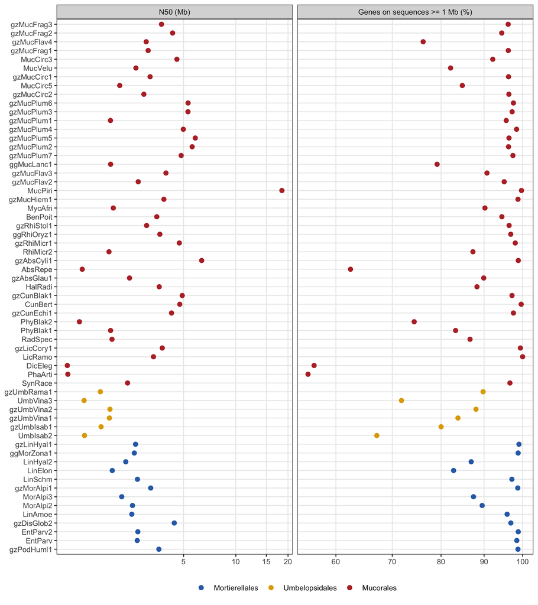

**Figure 1.** Assembly contiguity of the 61 genomes, in species-tree order. Left: scaffold/contig N50 (log scale). Right: percentage of genes on sequences of at least 1 Mb, the sequences on which collinear blocks can be detected. Colour: order.

```r
cont_long <- rbind(
  gen[, .(genome, order, metric = "N50 (Mb)", value = n50_mb)],
  gen[, .(genome, order, metric = "Genes on sequences >= 1 Mb (%)", value = 100 * on_1mb)])
cont_long[, metric := factor(metric, c("N50 (Mb)", "Genes on sequences >= 1 Mb (%)"))]
cont_long[, genome := factor(genome, tip_order)]
ggplot(cont_long, aes(value, genome, colour = order)) +
  geom_point(size = 2) +
  facet_wrap(~metric, scales = "free_x") +
  scale_x_continuous(trans = scales::transform_pseudo_log(sigma = 0.1)) +
  scale_colour_manual(values = order_cols, name = NULL) +
  labs(x = NULL, y = NULL) +
  theme(legend.position = "bottom")
```

## 1.2 Near-identical duplicates and assembly artifacts

Segmental duplicates here are collinear paralog blocks within one assembly (see Duplicate classes). Two copies of the same region in an assembly, for example uncollapsed haplotypes, also form such blocks, but with identical or nearly identical genes.

```r
ni <- pairs[near_ident == TRUE]
ni_sd <- ni[type == "SD", .(ni_sd = .N, ni_sd_seq_pairs = uniqueN(paste(pmin(seq1, seq2), pmax(seq1, seq2)))),
            by = genome]
gen <- merge(gen, ni_sd, by = "genome", all.x = TRUE)
gen[is.na(ni_sd), `:=`(ni_sd = 0L, ni_sd_seq_pairs = 0L)]
gen <- merge(gen, pairs[, .(pairs = .N, ni_all = sum(near_ident),
                            sd_old = sum(type == "SD" & !near_ident)), by = genome],
             by = "genome")
```

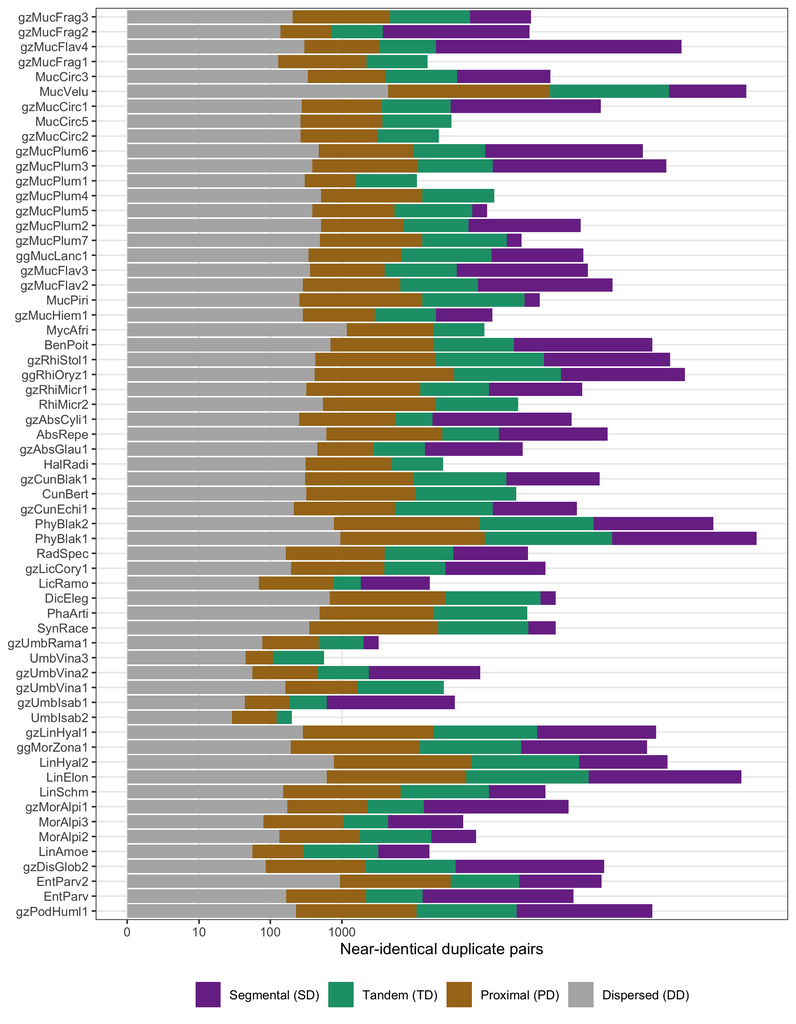

**Figure 2.** Near-identical duplicate pairs (Ks < 0.05, or Ks not estimable) per genome and duplication mode, in species-tree order (pseudo-log scale). Many near-identical segmental pairs indicate duplicated stretches of the assembly or very recent segmental duplications.

```r
ni_counts <- ni[, .N, by = .(genome, type)]
ni_counts[, `:=`(genome = factor(genome, tip_order), type = factor(type, mode_levels))]
ggplot(ni_counts, aes(N, genome, fill = type)) +
  geom_col() +
  scale_x_continuous(trans = scales::transform_pseudo_log(sigma = 1),
                     breaks = c(0, 10, 100, 1000)) +
  scale_fill_manual(values = mode_cols, labels = mode_labs, name = NULL, drop = TRUE) +
  labs(x = "Near-identical duplicate pairs", y = NULL) +
  theme(legend.position = "bottom")
```

Ks cannot be estimated for identical sequences, but also not for some very divergent ones. Protein sequences were compared for two genomes with many segmental pairs without Ks (Table 2).

```r
id_genomes <- c("gzMucFlav4", "gzMucCirc1")
id_files <- sprintf("data/doubletrouble/input_data/%s_data.rds",
                    gen$dt_id[match(id_genomes, gen$genome)])
fetch(id_files)
identity <- rbindlist(lapply(seq_along(id_genomes), function(i) {
  prot <- readRDS(id_files[i])$prot
  seqs <- setNames(as.character(prot), names(prot))
  p <- pairs[genome == id_genomes[i]]
  p[, identical_prot := seqs[dup1] == seqs[dup2]]
  p[, .(genome = id_genomes[i],
        mode = fifelse(type == "SD", "SD", "TD, PD, DD"),
        class = fcase(is.na(Ks), "Ks missing", Ks < 0.05, "Ks < 0.05", default = "Ks >= 0.05"),
        identical_prot)]
}))
stopifnot(!anyNA(identity$identical_prot))
id_tab <- identity[, .(pairs = .N, identical_protein_pct = round(100 * mean(identical_prot), 1)),
                   by = .(genome, mode, class)][order(genome, mode, class)]
id_sd_missing <- id_tab[mode == "SD" & class == "Ks missing"]
knitr::kable(id_tab, caption = tcap("identity", "Percentage of duplicate pairs with identical protein sequences, by mode and Ks class, in two genomes with many segmental pairs without Ks."))
```

Table 2. Percentage of duplicate pairs with identical protein sequences, by mode and Ks class, in two genomes with many segmental pairs without Ks.

| genome | mode | class | pairs | identical_protein_pct |
| --- | --- | --- | --- | --- |
| gzMucCirc1 | SD | Ks < 0.05 | 13 | 0.0 |
| gzMucCirc1 | SD | Ks >= 0.05 | 12 | 0.0 |
| gzMucCirc1 | SD | Ks missing | 112 | 82.1 |
| gzMucCirc1 | TD, PD, DD | Ks < 0.05 | 117 | 7.7 |
| gzMucCirc1 | TD, PD, DD | Ks >= 0.05 | 12001 | 0.4 |
| gzMucCirc1 | TD, PD, DD | Ks missing | 181 | 26.0 |
| gzMucFlav4 | SD | Ks < 0.05 | 146 | 10.3 |
| gzMucFlav4 | SD | Ks >= 0.05 | 39 | 2.6 |
| gzMucFlav4 | SD | Ks missing | 2577 | 89.1 |
| gzMucFlav4 | TD, PD, DD | Ks < 0.05 | 75 | 8.0 |
| gzMucFlav4 | TD, PD, DD | Ks >= 0.05 | 12691 | 0.4 |
| gzMucFlav4 | TD, PD, DD | Ks missing | 241 | 37.8 |

```r
flag_tab <- gen[ni_sd >= 50 | (!is.na(busco_dup) & busco_dup > 5),
                .(genome, order, contigs = n_seq, N50_Mb = round(n50_mb, 2),
                  SD_pairs = ni_sd + sd_old, near_identical_SD = ni_sd,
                  sequence_pairs = ni_sd_seq_pairs, BUSCO_dup_pct = busco_dup)][order(-near_identical_SD)]
knitr::kable(flag_tab, caption = tcap("flags", "Genomes flagged for many near-identical segmental pairs (at least 50) or more than 5% duplicated BUSCO genes. sequence_pairs: number of distinct pairs of assembly sequences that carry the near-identical SD pairs. BUSCO values are available only for part of our own assemblies."))
```

Table 1. Genomes flagged for many near-identical segmental pairs (at least 50) or more than 5% duplicated BUSCO genes. sequence_pairs: number of distinct pairs of assembly sequences that carry the near-identical SD pairs. BUSCO values are available only for part of our own assemblies.

| genome | order | contigs | N50_Mb | SD_pairs | near_identical_SD | sequence_pairs | BUSCO_dup_pct |
| --- | --- | --- | --- | --- | --- | --- | --- |
| gzMucFlav4 | Mucorales | 125 | 3.04 | 2762 | 2723 | 112 | NA |
| gzMucPlum3 | Mucorales | 29 | 5.30 | 265 | 265 | 24 | NA |
| gzMucPlum6 | Mucorales | 21 | 5.31 | 159 | 159 | 14 | NA |
| LinElon | Mortierellales | 79 | 1.94 | 841 | 137 | 27 | NA |
| EntParv | Mortierellales | 104 | 2.70 | 550 | 128 | 16 | NA |
| gzMucCirc1 | Mucorales | 48 | 3.20 | 137 | 125 | 9 | 1.2 |
| gzDisGlob2 | Mortierellales | 30 | 4.42 | 530 | 119 | 11 | NA |
| gzMucFrag2 | Mucorales | 23 | 4.32 | 119 | 112 | 7 | NA |
| gzMorAlpi1 | Mortierellales | 22 | 3.23 | 763 | 105 | 7 | 3.2 |
| PhyBlak1 | Mucorales | 116 | 1.89 | 180 | 104 | 17 | NA |
| gzAbsCyli1 | Mucorales | 34 | 6.36 | 1617 | 88 | 20 | 13.1 |
| BenPoit | Mucorales | 20 | 3.50 | 101 | 86 | 7 | NA |
| gzPodHuml1 | Mortierellales | 34 | 3.60 | 631 | 79 | 11 | 2.4 |
| gzMucFlav2 | Mucorales | 49 | 2.74 | 105 | 76 | 9 | NA |
| gzMucFlav3 | Mucorales | 30 | 3.95 | 73 | 68 | 5 | NA |
| gzUmbIsab1 | Umbelopsidales | 27 | 1.67 | 62 | 61 | 3 | 0.8 |
| gzRhiStol1 | Mucorales | 32 | 3.06 | 379 | 58 | 9 | 6.1 |
| ggMorZona1 | Mortierellales | 34 | 2.60 | 830 | 57 | 12 | 2.2 |
| ggRhiOryz1 | Mucorales | 22 | 3.65 | 1334 | 54 | 21 | 8.3 |

## 1.3 Contiguity and segmental duplicates

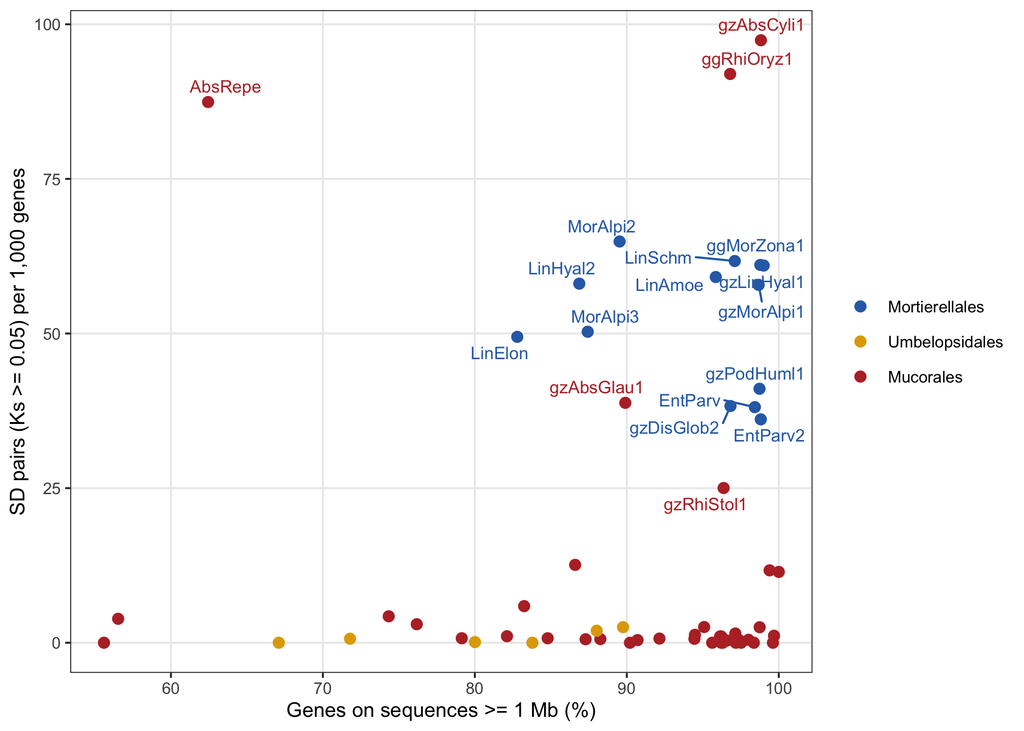

**Figure 3.** Segmental duplicate pairs with Ks >= 0.05 per 1,000 genes against the percentage of genes on sequences of at least 1 Mb. Each point is a genome; genomes with more than 20 pairs per 1,000 genes are labelled.

```r
gen[, sd_per_1k := 1000 * sd_old / genes]
ggplot(gen, aes(100 * on_1mb, sd_per_1k, colour = order)) +
  geom_point(size = 2.2) +
  geom_text_repel(data = gen[sd_per_1k > 20], aes(label = genome), size = 3,
                  show.legend = FALSE, max.overlaps = 30) +
  scale_colour_manual(values = order_cols, name = NULL) +
  labs(x = "Genes on sequences >= 1 Mb (%)", y = "SD pairs (Ks >= 0.05) per 1,000 genes")
```

```r
# Well-assembled genomes: at least 75% of genes on sequences >= 1 Mb. (The
# Umbelopsidales genomes are small, with chromosomes of 1-2 Mb, so a stricter
# cutoff would exclude all of them.)
hi_cont <- gen[on_1mb >= 0.75]
sd_by_order_hi <- hi_cont[, .(n = .N, median_sd_per_1k = median(sd_per_1k)), by = order][order(order)]
# Share of segmental pairs that are near-identical, per order
sd_ni_share <- pairs[type == "SD"][gen[, .(genome, order)], on = "genome", nomatch = NULL][
  , .(share = mean(near_ident)), by = .(genome, order)][, .(median_share = median(share)), by = order]
```

## 1.4 Genomes of the same species

Several species are represented by more than one genome. These genomes are not independent samples of duplicate content, and gene-tree duplications at their common ancestor are likely to be noise (Table 3).

```r
strains <- gen[, .(genomes = paste(sort(genome), collapse = ", "), n = .N), by = .(species, order)][n > 1][order(order, species)]
knitr::kable(strains[, .(species, order, genomes)],
             caption = tcap("strains", "Species represented by more than one genome."))
```

Table 3. Species represented by more than one genome.

| species | order | genomes |
| --- | --- | --- |
| Entomortierella parvispora | Mortierellales | EntParv, EntParv2 |
| Linnemannia hyalina | Mortierellales | LinHyal2, gzLinHyal1 |
| Mortierella alpina | Mortierellales | MorAlpi2, MorAlpi3, gzMorAlpi1 |
| Umbelopsis isabellina | Umbelopsidales | UmbIsab2, gzUmbIsab1 |
| Umbelopsis vinacea | Umbelopsidales | UmbVina3, gzUmbVina1, gzUmbVina2 |
| Mucor circinelloides | Mucorales | MucCirc5, gzMucCirc1, gzMucCirc2 |
| Mucor flavus | Mucorales | gzMucFlav2, gzMucFlav3, gzMucFlav4 |
| Mucor fragilis | Mucorales | gzMucFrag1, gzMucFrag2, gzMucFrag3 |
| Mucor plumbeus | Mucorales | gzMucPlum1, gzMucPlum2, gzMucPlum3, gzMucPlum4, gzMucPlum5, gzMucPlum6, gzMucPlum7 |
| Phycomyces blakesleeanus | Mucorales | PhyBlak1, PhyBlak2 |
| Rhizopus microsporus | Mucorales | RhiMicr2, gzRhiMicr1 |

## 1.5 Conclusion

```r
n_hi <- nrow(hi_cont)
flav4 <- gen[genome == "gzMucFlav4"]
mort_hi <- sd_by_order_hi[order == "Mortierellales"]
muc_hi  <- sd_by_order_hi[order == "Mucorales"]
umb_hi  <- sd_by_order_hi[order == "Umbelopsidales"]
```

- 55 of the 61 assemblies have at least 75% of their genes on sequences of 1 Mb or more (Figure 1), so collinear blocks can be detected in most genomes.
- Among these well-assembled genomes, segmental duplicates with Ks >= 0.05 are common in Mortierellales (median 57.9 pairs per 1,000 genes, n = 13) and rare in Umbelopsidales (1, n = 4) and most Mucorales (0.7, n = 38) (Figure 3). The exceptions are *Absidia* and *Rhizopus*. The scarcity of segmental duplicates in Mucorales and Umbelopsidales is therefore not an assembly artifact.
- In Mucorales, a large share of the few segmental pairs are near-identical (median 36% of SD pairs per genome, against 6% in Mortierellales): recent segmental duplicates or duplicated assembly sequences rather than old collinear blocks.
- gzMucFlav4 has 2723 near-identical segmental pairs spread over 112 pairs of sequences in a 125-sequence assembly, and 89.1% of its segmental pairs without Ks have identical proteins (Table 2). This points to duplicated (uncollapsed haplotype) sequences in the assembly. Near-identical pairs (Ks < 0.05 or missing) are kept as a separate category in all analyses below, and gzMucFlav4 should be checked before it is used in gene-count comparisons.
- 11 species are represented by more than one genome (Table 3); comparisons across genomes should treat them as one sample or use phylogenetic methods.

# 2 Duplicate landscape per species

Each duplicated gene was assigned one mode, with the priority used by doubletrouble’s `classify_genes()`: SD > TD > PD > DD (definitions in Duplicate classes). Near-identical pairs were counted only for genes that are in no older pair.

```r
gpairs <- rbind(pairs[, .(genome, gene = dup1, type, near_ident)],
                pairs[, .(genome, gene = dup2, type, near_ident)])
gpairs[, mode := fifelse(near_ident, "Near-identical", type)]
gpairs[, rank := match(mode, mode_levels)]
gmode <- gpairs[, .(mode = mode[which.min(rank)]), by = .(genome, gene)]
land <- gmode[, .N, by = .(genome, mode)]
land <- merge(land, gen[, .(genome, genes, order)], by = "genome")
land[, pct := 100 * N / genes]
land_wide <- dcast(land, genome + order + genes ~ mode, value.var = "pct", fill = 0)
for (m in mode_levels) if (!m %in% names(land_wide)) land_wide[, (m) := 0]
land_wide[, dup_pct := SD + TD + PD + DD]
```

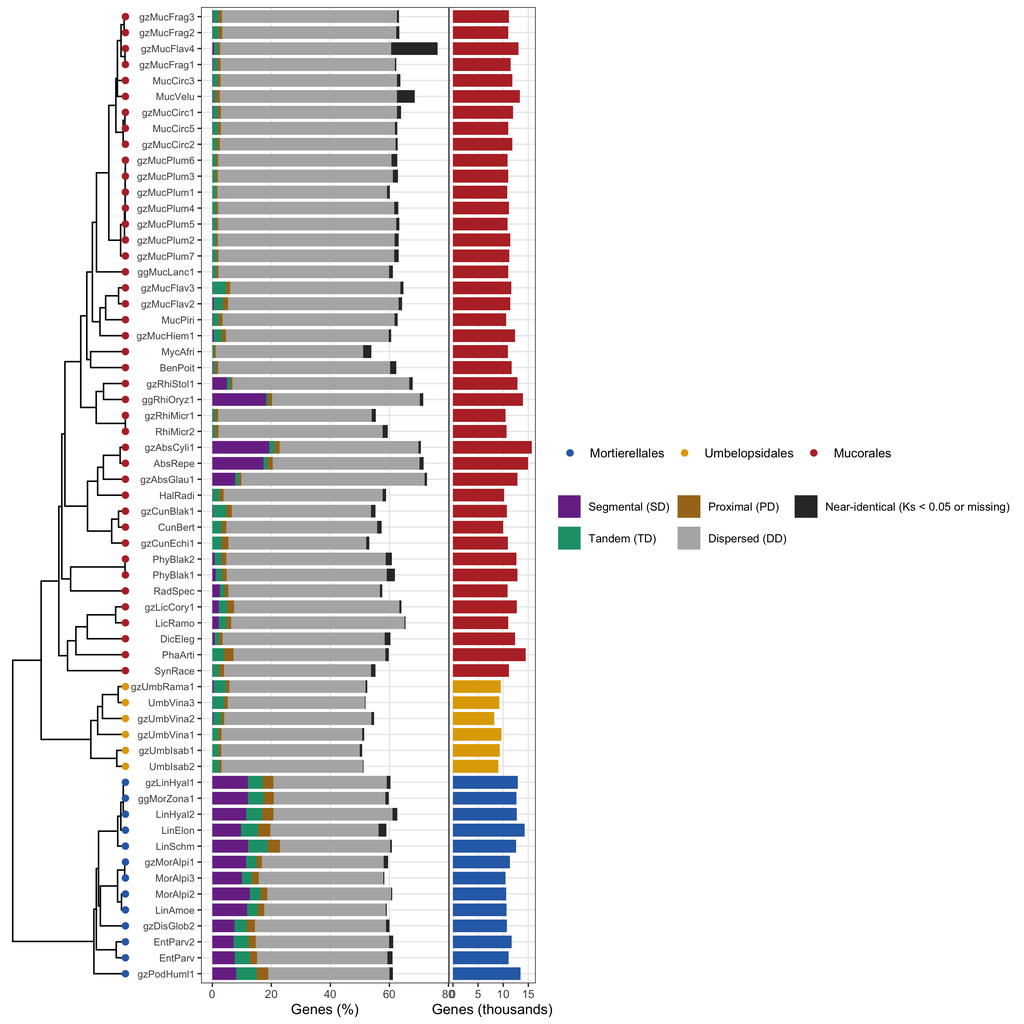

**Figure 4.** Duplicated genes per genome on the dated species tree. Middle: percentage of genes in each duplication mode (each gene counted once, priority SD > TD > PD > DD; near-identical only for genes in no older pair). Right: number of protein-coding genes. Tip colour: order.

```r
tip_df <- data.frame(label = gen$genome, order = gen$order)
p_tree <- ggtree(tree) %<+% tip_df +
  geom_tippoint(aes(colour = order), size = 1.8) +
  scale_colour_manual(values = order_cols, name = NULL) +
  theme(legend.position = "bottom")
p_modes <- ggplot(land[, .(genome, mode = factor(mode, rev(mode_levels)), pct)],
                  aes(pct, genome, fill = mode)) +
  geom_col(width = 0.8) +
  scale_fill_manual(values = mode_cols, labels = mode_labs, name = NULL, breaks = mode_levels) +
  labs(x = "Genes (%)", y = NULL) +
  theme(legend.position = "bottom", axis.text.y = element_text(size = 7)) +
  guides(fill = guide_legend(nrow = 2))
p_genes <- ggplot(gen, aes(genes / 1000, genome, fill = order)) +
  geom_col(width = 0.8, show.legend = FALSE) +
  scale_fill_manual(values = order_cols) +
  labs(x = "Genes (thousands)", y = NULL) +
  theme(axis.text.y = element_blank(), axis.ticks.y = element_blank())
p_modes %>% insert_left(p_tree, width = 0.5) %>% insert_right(p_genes, width = 0.35)
```

```r
ord_tab <- land_wide[, .(genomes = .N,
                         genes = median(genes),
                         duplicated = median(dup_pct), SD = median(SD), TD = median(TD),
                         PD = median(PD), DD = median(DD), near_identical = median(`Near-identical`)),
                     by = order][order(order)]
num <- names(ord_tab)[sapply(ord_tab, is.numeric)]
ord_tab[, (num) := lapply(.SD, round, 1), .SDcols = num]
knitr::kable(ord_tab, caption = tcap("orders", "Median number of genes and median percentage of genes in each duplication mode, per order."))
```

Table 4. Median number of genes and median percentage of genes in each duplication mode, per order.

| order | genomes | genes | duplicated | SD | TD | PD | DD | near_identical |
| --- | --- | --- | --- | --- | --- | --- | --- | --- |
| Mortierellales | 13 | 11655 | 59.1 | 11.4 | 5.0 | 2.8 | 41.1 | 1.2 |
| Umbelopsidales | 6 | 9290 | 51.3 | 0.1 | 2.4 | 1.1 | 47.3 | 0.6 |
| Mucorales | 42 | 11280 | 61.6 | 0.2 | 1.6 | 1.2 | 57.9 | 1.2 |

## 2.1 Gene number and duplicated genes

Do genomes with more genes have more duplicated genes, and of which mode? The slopes in Table 5 are from phylogenetic generalised least squares (Brownian motion on the dated tree), so related genomes are not counted as independent.

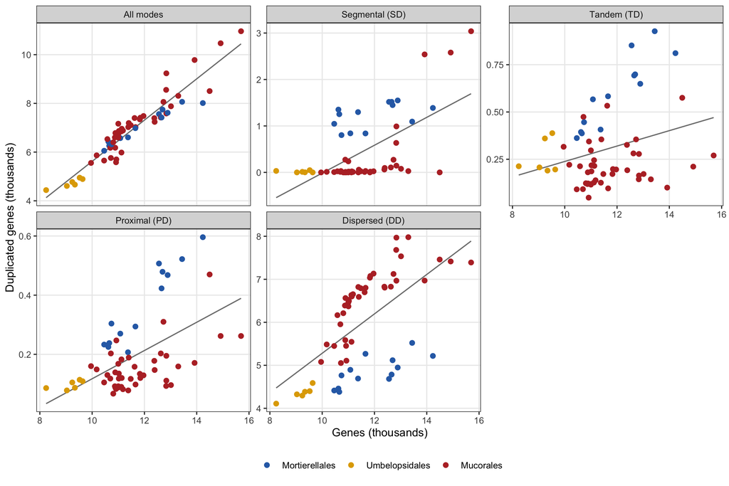

**Figure 5.** Duplicated genes (excluding near-identical) against the number of genes, per duplication mode and in total. Each point is a genome; lines are ordinary least-squares fits across all 61 genomes, shown for orientation (phylogenetic fits in Table 5).

```r
dup_counts <- dcast(land, genome + order + genes ~ mode, value.var = "N", fill = 0)
for (m in mode_levels) if (!m %in% names(dup_counts)) dup_counts[, (m) := 0]
dup_counts[, All := SD + TD + PD + DD]
dlong <- melt(dup_counts, id.vars = c("genome", "order", "genes"),
              measure.vars = c("All", "SD", "TD", "PD", "DD"), variable.name = "mode", value.name = "dup_genes")
dlong[, mode := factor(mode, c("All", "SD", "TD", "PD", "DD"),
                       c("All modes", mode_labs[c("SD", "TD", "PD", "DD")]))]
ggplot(dlong, aes(genes / 1000, dup_genes / 1000)) +
  geom_smooth(method = "lm", se = FALSE, colour = "grey50", linewidth = 0.5) +
  geom_point(aes(colour = order), size = 1.8) +
  facet_wrap(~mode, scales = "free_y", nrow = 2) +
  scale_colour_manual(values = order_cols, name = NULL) +
  labs(x = "Genes (thousands)", y = "Duplicated genes (thousands)") +
  theme(legend.position = "bottom")
```

```r
pgls_fit <- function(y) {
  df <- as.data.frame(dup_counts[, .(genome, genes, y = get(y))])
  fit <- gls(y ~ genes, data = df, correlation = corBrownian(1, phy = tree, form = ~genome))
  ct <- summary(fit)$tTable
  data.table(mode = y, slope = ct["genes", "Value"], se = ct["genes", "Std.Error"],
             p = ct["genes", "p-value"])
}
pg <- rbindlist(lapply(c("All", "SD", "TD", "PD", "DD"), pgls_fit))
fmt_p <- function(p) vapply(p, function(x) format(signif(x, 2), scientific = x < 0.001), "")
pg_show <- pg[, .(mode, `duplicated genes per extra gene` = round(slope, 3),
                  SE = round(se, 3), p = fmt_p(p))]
knitr::kable(pg_show, caption = tcap("pgls", "Phylogenetic regression of the number of duplicated genes on the number of genes (61 genomes). The slope is the number of additional duplicated genes per additional gene."))
```

Table 5. Phylogenetic regression of the number of duplicated genes on the number of genes (61 genomes). The slope is the number of additional duplicated genes per additional gene.

| mode | duplicated genes per extra gene | SE | p |
| --- | --- | --- | --- |
| All | 0.742 | 0.064 | 5.8e-17 |
| SD | 0.103 | 0.028 | 4.9e-04 |
| TD | 0.016 | 0.007 | 0.035 |
| PD | 0.013 | 0.006 | 0.022 |
| DD | 0.611 | 0.065 | 2.7e-13 |

## 2.2 Conclusion

```r
o <- function(ord, col) ord_tab[order == ord][[col]]
s <- function(m) pg[mode == m]
dd_share <- s("DD")$slope / s("All")$slope
sd_share <- s("SD")$slope / s("All")$slope
dup_range <- range(land_wide$dup_pct)
top_muc <- gen[order == "Mucorales"][order(-genes)][1:4]
top_sd <- top_muc[sd_per_1k > 20, genome]
top_other <- top_muc[sd_per_1k <= 20, genome]
```

Here “duplicated” means being in any paralogous pair that doubletrouble detected (one of a gene’s top 5 within-genome DIAMOND hits at E <= 1e-10), which includes old and divergent paralogs.

- The duplicated fraction of the genome is similar across orders: median 59.1% of genes in Mortierellales, 51.3% in Umbelopsidales and 61.6% in Mucorales (Table 4). Most duplicated genes are dispersed in all three orders.
- Segmental duplicates make up a visible share only in Mortierellales (median 11.4% of genes) and in a few Mucorales genomes (*Absidia*, *Rhizopus*; Figure 4); in most Mucorales and in all Umbelopsidales they are below 1%.
- Genomes with more genes have more duplicated genes (0.74 duplicated genes per additional gene, p = 5.8e-17; Table 5). Dispersed duplicates account for about 82% of that slope and segmental duplicates for 14%, so variation in gene number is mostly variation in dispersed duplicates (Figure 5).
- At the top of the range this differs: 3 of the 4 Mucorales genomes with the most genes (gzAbsCyli1, AbsRepe, ggRhiOryz1) have many segmental duplicates (more than 20 pairs per 1,000 genes); the other, PhaArti, does not. This makes *Absidia* and *Rhizopus* candidates for lineage-specific WGDs (to be dated with Ks in Section 3).
- Mortierellales have more segmental, tandem and proximal duplicates and fewer dispersed ones than Mucorales of the same gene number, so their total duplicated fraction is similar (Figure 5).

# 3 Ks age distributions

Ks, the number of synonymous substitutions per synonymous site between the two copies, grows with the age of a duplicate pair until it saturates at about Ks 2, beyond which the estimates mostly reflect noise. A WGD leaves many pairs of the same age, so a peak in the Ks distribution; small-scale duplication leaves a smooth distribution of mostly young pairs. All pairs with Ks >= 0.05 were used (near-identical pairs excluded); Ks values up to 5 are shown, so that the saturated pairs are visible as their own group.

```r
ksd <- pairs[!near_ident & Ks <= 5]
ksd[, class := fifelse(type == "SD", "Segmental (SD)", "Small-scale (TD, PD, DD)")]
ksd <- merge(ksd, gen[, .(genome, genes, order)], by = "genome")
```

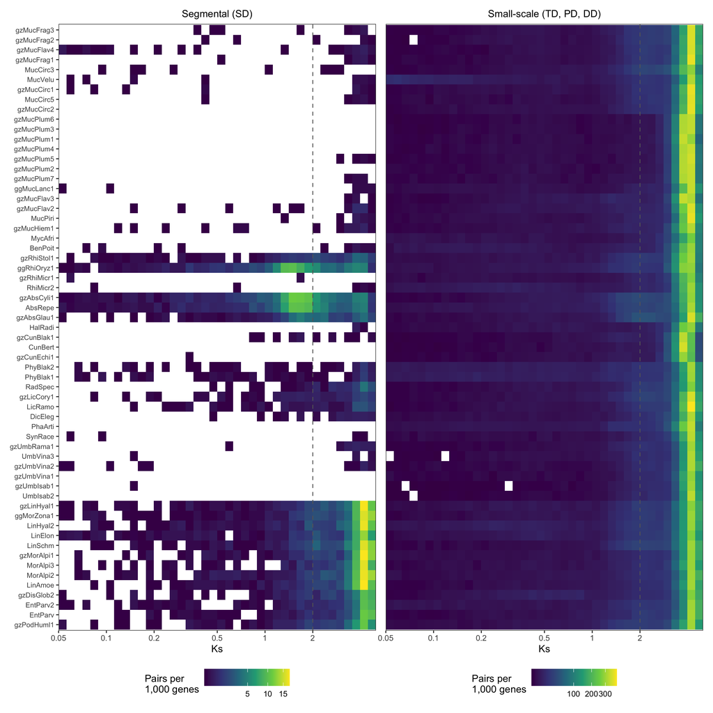

**Figure 6.** Ks distributions of segmental (left) and small-scale (right) duplicate pairs per genome, in species-tree order. Colour: pairs per 1,000 genes in each Ks bin (log-spaced bins; square-root colour scale, separate for the two panels; white: no pairs). Pairs with Ks < 0.05 or without Ks are excluded. Dashed line: Ks = 2, above which Ks is saturated.

```r
breaks <- seq(log10(0.05), log10(5), length.out = 41)
ksd[, bin := cut(log10(Ks), breaks, include.lowest = TRUE, labels = FALSE)]
heat <- ksd[, .(n = .N), by = .(genome, class, bin, genes)]
heat[, per_1k := 1000 * n / genes]
heat[, `:=`(x = (breaks[bin] + breaks[bin + 1]) / 2, genome = factor(genome, tip_order))]
heat_panel <- function(cl, show_y = TRUE) {
  ggplot(heat[class == cl], aes(x, genome, fill = per_1k)) +
    geom_tile() +
    geom_vline(xintercept = log10(2), linetype = "dashed", linewidth = 0.4, colour = "grey40") +
    scale_x_continuous(breaks = log10(c(0.05, 0.1, 0.2, 0.5, 1, 2, 5)),
                       labels = c(0.05, 0.1, 0.2, 0.5, 1, 2, 5), expand = c(0, 0)) +
    scale_y_discrete(drop = FALSE) +
    scale_fill_viridis_c(trans = "sqrt", name = "Pairs per\n1,000 genes") +
    labs(x = "Ks", y = NULL, title = cl) +
    theme(axis.text.y = if (show_y) element_text(size = 7) else element_blank(),
          axis.ticks.y = if (show_y) element_line() else element_blank(),
          panel.grid = element_blank(), legend.position = "bottom",
          plot.title = element_text(size = 10, hjust = 0.5))
}
heat_panel("Segmental (SD)") + heat_panel("Small-scale (TD, PD, DD)", show_y = FALSE)
```

## 3.1 Peaks in the segmental Ks distributions

Peaks were fitted with Gaussian mixture models (mclust, as in doubletrouble’s `find_ks_peaks()`), but on log Ks and over the range 0.05-5, so that the saturated pairs get their own component instead of pulling a component towards the cut-off. The number of components (1-4) was chosen by BIC. Only genomes with at least 100 segmental pairs were fitted.

```r
fit_peaks <- function(ks) {
  m <- densityMclust(log(ks), G = 1:4, modelNames = "V", verbose = FALSE, plot = FALSE)
  o <- order(m$parameters$mean)
  data.table(component = seq_along(o), mean_log = m$parameters$mean[o],
             sd_log = sqrt(m$parameters$variance$sigmasq[o]), weight = m$parameters$pro[o])
}
sd_n <- ksd[class == "Segmental (SD)", .N, by = genome]
peak_genomes <- intersect(tip_order, sd_n[N >= 100, genome])
peaks <- rbindlist(lapply(peak_genomes, function(g) {
  fit_peaks(ksd[genome == g & class == "Segmental (SD)", Ks])[, genome := g]
}))
peaks[, Ks := exp(mean_log)]
# The main sub-saturation peak: the largest component with mean Ks < 2
main_peak <- peaks[Ks < 2][order(-weight)][, .SD[1], by = genome]
peak_tab <- peaks[, .(components = paste(sprintf("%.2f (%.0f%%)", Ks, 100 * weight), collapse = ", ")),
                  by = genome]
peak_tab <- merge(peak_tab, sd_n, by = "genome")
peak_tab <- merge(peak_tab, main_peak[, .(genome, main_Ks = round(Ks, 2), main_weight = round(weight, 2))],
                  by = "genome", all.x = TRUE)
peak_tab <- merge(gen[, .(genome, order)], peak_tab, by = "genome")[order(order, -main_weight)]
knitr::kable(peak_tab[, .(genome, order, SD_pairs = N, components, main_Ks, main_weight)],
             caption = tcap("peaks", "Gaussian mixture components of the log-Ks distribution of segmental pairs (Ks 0.05-5): component mean Ks and weight. main_Ks and main_weight: the largest component with mean Ks < 2."))
```

Table 6. Gaussian mixture components of the log-Ks distribution of segmental pairs (Ks 0.05-5): component mean Ks and weight. main_Ks and main_weight: the largest component with mean Ks < 2.

| genome | order | SD_pairs | components | main_Ks | main_weight |
| --- | --- | --- | --- | --- | --- |
| LinSchm | Mortierellales | 744 | 1.69 (32%), 3.72 (28%), 4.41 (40%) | 1.69 | 0.32 |
| gzMorAlpi1 | Mortierellales | 625 | 1.63 (26%), 3.92 (36%), 4.46 (38%) | 1.63 | 0.26 |
| LinElon | Mortierellales | 685 | 0.25 (12%), 2.12 (24%), 3.87 (35%), 4.41 (29%) | 0.25 | 0.12 |
| MorAlpi2 | Mortierellales | 653 | 0.59 (10%), 2.45 (21%), 3.93 (36%), 4.50 (33%) | 0.59 | 0.10 |
| LinHyal2 | Mortierellales | 717 | 0.49 (8%), 2.10 (20%), 3.61 (23%), 4.33 (49%) | 0.49 | 0.08 |
| EntParv2 | Mortierellales | 398 | 0.29 (7%), 2.16 (19%), 3.81 (26%), 4.45 (48%) | 0.29 | 0.07 |
| LinAmoe | Mortierellales | 603 | 0.64 (7%), 2.27 (20%), 3.83 (34%), 4.37 (39%) | 0.64 | 0.07 |
| gzLinHyal1 | Mortierellales | 758 | 0.45 (7%), 2.32 (26%), 3.82 (29%), 4.40 (38%) | 0.45 | 0.07 |
| gzPodHuml1 | Mortierellales | 534 | 0.48 (7%), 2.27 (30%), 4.11 (63%) | 0.48 | 0.07 |
| ggMorZona1 | Mortierellales | 740 | 0.38 (6%), 2.27 (26%), 3.97 (38%), 4.52 (29%) | 0.38 | 0.06 |
| EntParv | Mortierellales | 400 | 0.34 (5%), 2.48 (27%), 4.22 (54%), 4.74 (13%) | 0.34 | 0.05 |
| MorAlpi3 | Mortierellales | 512 | 0.36 (4%), 2.37 (21%), 3.85 (36%), 4.39 (38%) | 0.36 | 0.04 |
| gzDisGlob2 | Mortierellales | 395 | 0.22 (4%), 2.20 (31%), 3.88 (29%), 4.49 (36%) | 0.22 | 0.04 |
| AbsRepe | Mucorales | 1302 | 0.46 (17%), 1.71 (69%), 3.90 (14%) | 1.71 | 0.69 |
| gzAbsGlau1 | Mucorales | 497 | 0.57 (11%), 1.91 (69%), 4.11 (21%) | 1.91 | 0.69 |
| ggRhiOryz1 | Mucorales | 1276 | 0.54 (20%), 1.63 (63%), 3.76 (17%) | 1.63 | 0.63 |
| gzRhiStol1 | Mucorales | 318 | 0.25 (12%), 1.98 (54%), 3.99 (34%) | 1.98 | 0.54 |
| gzAbsCyli1 | Mucorales | 1527 | 0.44 (15%), 1.64 (21%), 1.75 (53%), 3.96 (10%) | 1.75 | 0.53 |
| LicRamo | Mucorales | 124 | 1.28 (45%), 4.10 (55%) | 1.28 | 0.45 |
| gzLicCory1 | Mucorales | 145 | 0.47 (14%), 2.07 (48%), 4.16 (38%) | 0.47 | 0.14 |
| RadSpec | Mucorales | 134 | 0.71 (3%), 2.75 (41%), 4.29 (56%) | 0.71 | 0.03 |

## 3.2 Placing the peaks relative to speciation

A duplication peak is older than a speciation event if its Ks is larger than the Ks between orthologs of the two species, and younger if it is smaller (assuming similar substitution rates in the lineages). One-to-one orthologs (OrthoFinder) were sampled for pairs of species that bracket the candidate events, and Ks was computed in the same way as for the paralogs (MYN model; 400 random orthologs per pair). The comparisons with Umbelopsidales and Mortierellales span the branches where Corrochano et al. placed their WGD.

```r
orth_pairs <- data.table(
  a = c("gzAbsCyli1", "AbsRepe", "AbsRepe", "ggRhiOryz1", "ggRhiOryz1", "AbsRepe",
        "ggMorZona1", "ggRhiOryz1", "ggRhiOryz1",
        "ggMorZona1", "ggMorZona1", "ggMorZona1", "gzMorAlpi1", "ggMorZona1",
        "gzMucCirc1", "gzMucCirc1", "gzMucCirc1",
        # splits at ages 70-190, to fill the gap in Ks against split age
        "gzMucFrag1", "UmbIsab2", "EntParv", "gzMucFrag1", "LicRamo", "gzCunBlak1",
        "gzMucFrag1", "gzMucFlav2"),
  b = c("AbsRepe", "gzAbsGlau1", "HalRadi", "gzRhiStol1", "gzRhiMicr1", "ggRhiOryz1",
        "gzPodHuml1", "gzUmbVina1", "ggMorZona1",
        "gzLinHyal1", "LinElon", "LinSchm", "gzDisGlob2", "gzMorAlpi1",
        "gzMucHiem1", "BenPoit", "ggRhiOryz1",
        "MucVelu", "gzUmbIsab1", "EntParv2", "gzMucCirc1", "gzLicCory1", "gzCunEchi1",
        "gzMucPlum1", "MucPiri"),
  split = c("Within Absidia (A. cylindrospora / A. repens)", "Within Absidia (A. repens / A. glauca)",
            "Absidia / Halteromyces", "Within Rhizopus (R. oryzae / R. stolonifer)",
            "Within Rhizopus (R. oryzae / R. microsporus)", "Absidia / Rhizopus",
            "Mortierellales crown", "Mucorales / Umbelopsidales", "Mucorales / Mortierellales",
            "Within Mortierellales (M. zonata / L. hyalina)", "Within Mortierellales (M. zonata / L. elongata)",
            "Within Mortierellales (M. zonata / L. schmuckeri)", "Within Mortierellales (M. alpina / D. globulifera)",
            "Within Mortierellales (M. zonata / M. alpina)", "Within Mucoraceae (M. circinelloides / M. hiemalis)",
            "Within Mucoraceae (M. circinelloides / B. poitrasii)", "Mucor / Rhizopus",
            "Within Mucor (M. fragilis / M. velutinosus)", "Within Umbelopsis (U. isabellina strains)",
            "Within Mortierellales (E. parvispora strains)", "Within Mucor (M. fragilis / M. circinelloides)",
            "Within Lichtheimia (L. ramosa / L. corymbifera)", "Within Cunninghamella (C. blakesleeana / C. echinulata)",
            "Within Mucor (M. fragilis / M. plumbeus)", "Within Mucor (M. flavus / M. piriformis)"))
# Age of each split on the dated tree (relative time, root = 1,000)
orth_pairs[, age := round(max(node.depth.edgelength(tree)) -
                            node.depth.edgelength(tree)[getMRCA(tree, c(a, b))]), by = .(a, b)]

orth_path <- "data/genome_duplication/ortholog_ks.tsv"
# Computed once per species pair and cached; only pairs missing from the cache are computed
orth_done <- if (file.exists(orth_path)) unique(fread(orth_path)[, paste(a, b)]) else character()
orth_todo <- orth_pairs[!paste(a, b) %in% orth_done]
if (nrow(orth_todo) > 0) {
  load_cds <- function(g) {
    f <- sprintf("data/doubletrouble/input_data/%s_data.rds", gen[genome == g, dt_id])
    fetch(f)
    cds <- readRDS(f)$cds
    cds[Biostrings::width(cds) %% 3 == 0]  # as in pairs2kaks()
  }
  load_alias <- function(g) {  # any OrthoFinder identifier -> gene ID
    f <- sprintf("data/genomes/%1$s/%1$s_IDtbl.tsv", g)
    fetch(f)
    ids <- fread(f)
    unique(rbind(ids[, .(id = proteinID, gene = geneID)], ids[, .(id = rnaID, gene = geneID)],
                 ids[, .(id = geneID, gene = geneID)]))
  }
  # OrthoFinder separates genes with ", "; public FASTA headers carry descriptions,
  # so take the first word of each element that is a known identifier.
  known_id <- function(cell, known) {
    vapply(strsplit(cell, ", ", fixed = TRUE), function(p) {
      w <- sub(" .*", "", p); w <- w[w %in% known]
      if (length(w) == 1) w else NA_character_
    }, "")
  }
  n_genes_in <- function(cell) lengths(strsplit(cell, ", ", fixed = TRUE))
  ks_of_pairs <- function(cds_a, cds_b, ga, gb) {
    seqs <- c(cds_a[ga], cds_b[gb])
    names(seqs) <- c(paste0("a_", ga), paste0("b_", gb))
    idx <- lapply(seq_along(ga), function(i) c(i, length(ga) + i))
    r <- MSA2dist::indices2kaks(cds = seqs, indices = idx, model = "MYN", isMSA = FALSE,
                                threads = max(1, parallel::detectCores() - 1), verbose = FALSE)
    as.numeric(ifelse(r$Ks == "NA", NA, r$Ks))
  }
  ortholog_ks <- function(a, b, n = 400, seed = 1) {
    f <- sprintf("data/orthofinder/results/Orthologues/Orthologues_%1$s/%1$s__v__%2$s.tsv",
                 of_names[[a]], of_names[[b]])
    fetch(f)
    o <- fread(f, sep = "\t", header = TRUE, quote = "", col.names = c("og", "a", "b"))
    alias_a <- load_alias(a); alias_b <- load_alias(b)
    one <- o[n_genes_in(a) == 1 & n_genes_in(b) == 1]
    one[, `:=`(gene_a = alias_a$gene[match(known_id(a, alias_a$id), alias_a$id)],
               gene_b = alias_b$gene[match(known_id(b, alias_b$id), alias_b$id)])]
    cds_a <- load_cds(a); cds_b <- load_cds(b)
    one <- one[gene_a %in% names(cds_a) & gene_b %in% names(cds_b)]
    set.seed(seed)
    s <- one[sample(.N, min(n, .N))]
    data.table(a = a, b = b, one_to_one = nrow(one), gene_a = s$gene_a, gene_b = s$gene_b,
               Ks = ks_of_pairs(cds_a, cds_b, s$gene_a, s$gene_b))
  }
  orth_new <- rbindlist(lapply(seq_len(nrow(orth_todo)), function(i) {
    ortholog_ks(orth_todo$a[i], orth_todo$b[i])
  }))
  fwrite(rbind(if (file.exists(orth_path)) fread(orth_path) else NULL, orth_new), orth_path, sep = "\t")
}
orth_ks <- fread(orth_path)
orth_ks <- merge(orth_ks, orth_pairs, by = c("a", "b"))
orth_sum <- orth_ks[, .(age = age[1], one_to_one = one_to_one[1], sampled = .N,
                        Ks_q25 = quantile(Ks, 0.25, na.rm = TRUE), Ks_median = median(Ks, na.rm = TRUE),
                        Ks_q75 = quantile(Ks, 0.75, na.rm = TRUE),
                        saturated_pct = 100 * mean(Ks > 2, na.rm = TRUE)), by = .(split, a, b)]
# Peak of each ortholog distribution, fitted as for the paralogs (largest
# Gaussian component below Ks 3): near saturation the median is pulled up by
# saturated orthologs, so the peak is the value to compare with paralog peaks
orth_peak <- orth_ks[!is.na(Ks) & Ks >= 0.05 & Ks <= 5, {
  pk <- fit_peaks(Ks)[, Ks := exp(mean_log)][Ks < 3][order(-weight)]
  # reported only if this component holds at least half of the orthologs;
  # otherwise the distribution is mostly saturated and the peak is not a speciation
  if (nrow(pk) > 0 && pk$weight[1] >= 0.5) .(Ks_peak = pk$Ks[1], peak_weight = pk$weight[1])
  else .(Ks_peak = NA_real_, peak_weight = if (nrow(pk) > 0) pk$weight[1] else 0)
}, by = split]
orth_sum <- merge(orth_sum, orth_peak, by = "split")
orth_sum <- orth_sum[match(orth_pairs$split, split)]
orth_sum[, peak_weight := NULL]
setcolorder(orth_sum, c("split", "a", "b", "age", "one_to_one", "sampled", "Ks_peak"))
num <- c("Ks_q25", "Ks_median", "Ks_q75", "saturated_pct", "Ks_peak")
orth_sum[, (num) := lapply(.SD, round, 2), .SDcols = num]
local({ op <- options(knitr.kable.NA = ""); on.exit(options(op)); knitr::kable(orth_sum, caption = tcap("orthks", paste0("Ks between one-to-one orthologs of species pairs (400 random orthologs per pair; MYN model, as for the paralogs). age: age of the split on the dated tree (relative time, root = 1,000). Ks_peak: largest Gaussian mixture component below Ks 3, fitted as for the paralogs (", tab("peaks"), "), given only where it holds at least half of the orthologs; empty where the distribution is mostly saturated. one_to_one: number of one-to-one orthologs available. saturated_pct: percentage of orthologs with Ks > 2.")))})
```

Table 7. Ks between one-to-one orthologs of species pairs (400 random orthologs per pair; MYN model, as for the paralogs). age: age of the split on the dated tree (relative time, root = 1,000). Ks_peak: largest Gaussian mixture component below Ks 3, fitted as for the paralogs (Table 6), given only where it holds at least half of the orthologs; empty where the distribution is mostly saturated. one_to_one: number of one-to-one orthologs available. saturated_pct: percentage of orthologs with Ks > 2.

| split | a | b | age | one_to_one | sampled | Ks_peak | Ks_q25 | Ks_median | Ks_q75 | saturated_pct |
| --- | --- | --- | --- | --- | --- | --- | --- | --- | --- | --- |
| Within Absidia (A. cylindrospora / A. repens) | gzAbsCyli1 | AbsRepe | 47 | 10793 | 400 | 0.25 | 0.21 | 0.26 | 0.33 | 0.50 |
| Within Absidia (A. repens / A. glauca) | AbsRepe | gzAbsGlau1 | 195 | 7200 | 400 | 1.96 | 1.69 | 2.25 | 3.83 | 58.15 |
| Absidia / Halteromyces | AbsRepe | HalRadi | 246 | 5645 | 400 |  | 2.08 | 3.35 | 4.04 | 78.25 |
| Within Rhizopus (R. oryzae / R. stolonifer) | ggRhiOryz1 | gzRhiStol1 | 194 | 7330 | 400 | 1.76 | 1.54 | 2.12 | 3.38 | 51.91 |
| Within Rhizopus (R. oryzae / R. microsporus) | ggRhiOryz1 | gzRhiMicr1 | 259 | 5666 | 400 | 1.93 | 1.75 | 2.65 | 3.95 | 66.42 |
| Absidia / Rhizopus | AbsRepe | ggRhiOryz1 | 537 | 3234 | 400 |  | 3.52 | 3.88 | 4.34 | 96.25 |
| Mortierellales crown | ggMorZona1 | gzPodHuml1 | 280 | 7271 | 400 |  | 3.28 | 4.14 | 4.58 | 89.70 |
| Mucorales / Umbelopsidales | ggRhiOryz1 | gzUmbVina1 | 748 | 3422 | 400 |  | 3.56 | 3.99 | 4.36 | 98.99 |
| Mucorales / Mortierellales | ggRhiOryz1 | ggMorZona1 | 1000 | 2408 | 400 |  | 3.61 | 4.03 | 4.40 | 99.25 |
| Within Mortierellales (M. zonata / L. hyalina) | ggMorZona1 | gzLinHyal1 | 19 | 10436 | 400 | 0.12 | 0.10 | 0.12 | 0.15 | 0.50 |
| Within Mortierellales (M. zonata / L. elongata) | ggMorZona1 | LinElon | 41 | 9426 | 400 | 0.25 | 0.21 | 0.25 | 0.32 | 0.50 |
| Within Mortierellales (M. zonata / L. schmuckeri) | ggMorZona1 | LinSchm | 68 | 9689 | 400 | 0.48 | 0.39 | 0.50 | 0.69 | 2.26 |
| Within Mortierellales (M. alpina / D. globulifera) | gzMorAlpi1 | gzDisGlob2 | 222 | 7245 | 400 |  | 2.35 | 3.79 | 4.44 | 82.25 |
| Within Mortierellales (M. zonata / M. alpina) | ggMorZona1 | gzMorAlpi1 | 238 | 7606 | 400 |  | 2.70 | 4.02 | 4.48 | 87.50 |
| Within Mucoraceae (M. circinelloides / M. hiemalis) | gzMucCirc1 | gzMucHiem1 | 293 | 8588 | 400 |  | 3.30 | 3.96 | 4.30 | 86.73 |
| Within Mucoraceae (M. circinelloides / B. poitrasii) | gzMucCirc1 | BenPoit | 343 | 8006 | 400 |  | 3.27 | 3.95 | 4.30 | 88.16 |
| Mucor / Rhizopus | gzMucCirc1 | ggRhiOryz1 | 396 | 5377 | 400 |  | 3.39 | 3.97 | 4.34 | 93.00 |
| Within Mucor (M. fragilis / M. velutinosus) | gzMucFrag1 | MucVelu | 71 | 9984 | 400 | 0.42 | 0.33 | 0.43 | 0.56 | 1.01 |
| Within Umbelopsis (U. isabellina strains) | UmbIsab2 | gzUmbIsab1 | 76 | 7844 | 400 | 0.39 | 0.31 | 0.38 | 0.48 | 0.50 |
| Within Mortierellales (E. parvispora strains) | EntParv | EntParv2 | 81 | 8773 | 400 | 0.77 | 0.58 | 0.75 | 0.97 | 2.75 |
| Within Mucor (M. fragilis / M. circinelloides) | gzMucFrag1 | gzMucCirc1 | 85 | 9943 | 400 | 0.69 | 0.51 | 0.68 | 0.98 | 2.54 |
| Within Lichtheimia (L. ramosa / L. corymbifera) | LicRamo | gzLicCory1 | 87 | 9546 | 400 | 0.56 | 0.45 | 0.59 | 0.74 | 1.50 |
| Within Cunninghamella (C. blakesleeana / C. echinulata) | gzCunBlak1 | gzCunEchi1 | 122 | 8199 | 400 | 1.86 | 1.65 | 2.22 | 3.41 | 56.15 |
| Within Mucor (M. fragilis / M. plumbeus) | gzMucFrag1 | gzMucPlum1 | 147 | 8733 | 400 | 1.43 | 1.26 | 1.69 | 2.91 | 39.49 |
| Within Mucor (M. flavus / M. piriformis) | gzMucFlav2 | MucPiri | 175 | 8287 | 400 |  | 1.82 | 3.26 | 4.22 | 68.97 |

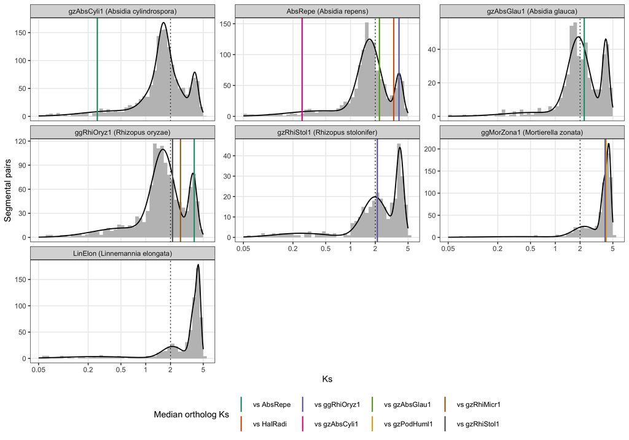

**Figure 7.** Ks distributions of segmental pairs (Ks 0.05-5, log scale) in the genomes with the most segmental pairs: Absidia and Rhizopus (Mucorales) and two Mortierellales for comparison. Grey: histogram; black curve: fitted Gaussian mixture; coloured vertical lines: median ortholog Ks to the species named (Table 7). Dotted line: Ks = 2.

```r
show <- c("gzAbsCyli1", "AbsRepe", "gzAbsGlau1", "ggRhiOryz1", "gzRhiStol1", "ggMorZona1", "LinElon")
bw <- 0.1
hist_d <- ksd[genome %in% show & class == "Segmental (SD)"]
curves <- rbindlist(lapply(show, function(g) {
  p <- peaks[genome == g]; n <- hist_d[genome == g, .N]
  x <- seq(log(0.05), log(5), length.out = 300)
  y <- rowSums(sapply(seq_len(nrow(p)), function(i) p$weight[i] * dnorm(x, p$mean_log[i], p$sd_log[i])))
  data.table(genome = g, x = x, y = y * n * bw)
}))
ref_lines <- orth_ks[, .(Ks = median(Ks, na.rm = TRUE)), by = .(a, b)]
ref_lines <- rbind(ref_lines[, .(genome = a, other = b, Ks)], ref_lines[, .(genome = b, other = a, Ks)])
ref_lines <- ref_lines[genome %in% show & other %in% c("gzAbsCyli1", "AbsRepe", "gzAbsGlau1", "HalRadi",
                                                         "ggRhiOryz1", "gzRhiStol1", "gzRhiMicr1", "gzPodHuml1")]
ref_lines[, label := paste("vs", other)]
facet_lab <- function(g) paste0(g, " (", gen$species[match(g, gen$genome)], ")")
hist_d[, panel := factor(facet_lab(genome), facet_lab(show))]
curves[, panel := factor(facet_lab(genome), facet_lab(show))]
ref_lines[, panel := factor(facet_lab(genome), facet_lab(show))]
ggplot(hist_d, aes(log(Ks))) +
  geom_histogram(binwidth = bw, boundary = log(0.05), fill = "grey75") +
  geom_line(data = curves, aes(x, y), linewidth = 0.6) +
  geom_vline(xintercept = log(2), linetype = "dotted") +
  geom_vline(data = ref_lines, aes(xintercept = log(Ks), colour = label), linewidth = 0.7) +
  facet_wrap(~panel, scales = "free_y", ncol = 3) +
  scale_x_continuous(breaks = log(c(0.05, 0.2, 0.5, 1, 2, 5)), labels = c(0.05, 0.2, 0.5, 1, 2, 5)) +
  scale_colour_brewer(palette = "Dark2", name = "Median ortholog Ks") +
  labs(x = "Ks", y = "Segmental pairs") +
  theme(legend.position = "bottom", strip.text = element_text(size = 8))
```

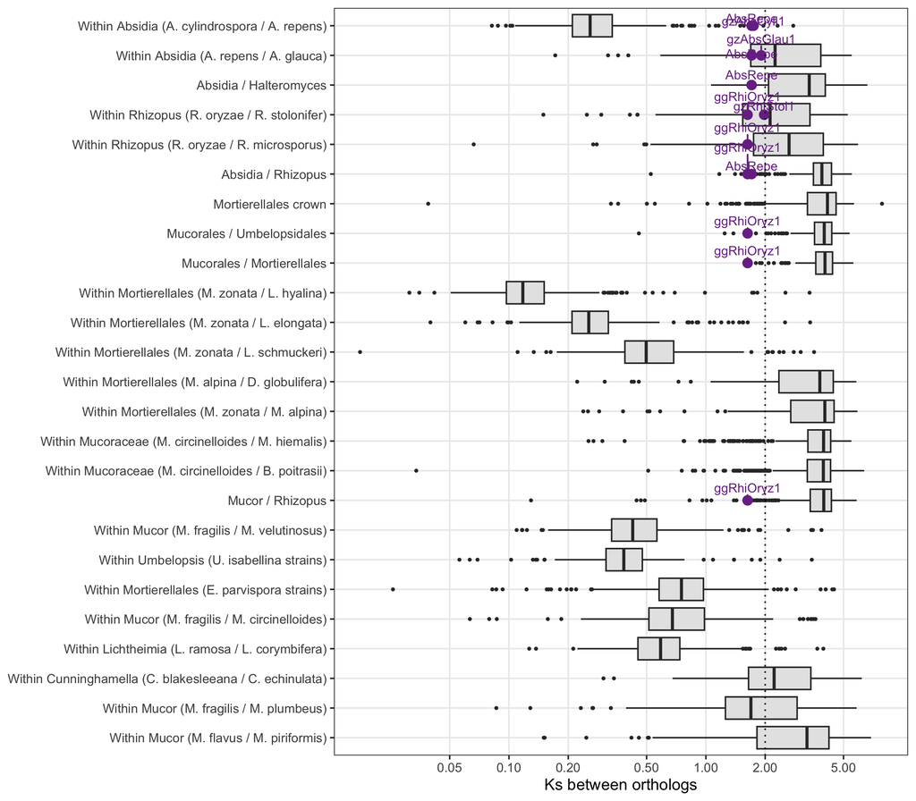

```r
orth_ks[, split_f := factor(split, rev(orth_pairs$split))]
pk_pts <- rbind(main_peak[, .(genome, Ks)][orth_pairs, on = c(genome = "a"), nomatch = NULL][, .(split, genome, Ks)],
                main_peak[, .(genome, Ks)][orth_pairs, on = c(genome = "b"), nomatch = NULL][, .(split, genome, Ks)])
pk_pts <- pk_pts[grepl("^(gzAbs|AbsRepe|ggRhi|gzRhi)", genome)]
pk_pts[, split_f := factor(split, levels(orth_ks$split_f))]
ggplot(orth_ks[Ks >= 0.01], aes(Ks, split_f)) +
  geom_boxplot(outlier.size = 0.5, fill = "grey90") +
  geom_point(data = pk_pts, colour = accent, size = 2.5) +
  geom_text_repel(data = pk_pts, aes(label = genome), colour = accent, size = 2.8,
                  direction = "y", nudge_y = 0.3, min.segment.length = 0) +
  geom_vline(xintercept = 2, linetype = "dotted") +
  scale_x_log10(breaks = c(0.05, 0.1, 0.2, 0.5, 1, 2, 5)) +
  labs(x = "Ks between orthologs", y = NULL)
```

## 3.3 Conclusion

```r
mp <- function(g) main_peak[genome == g]
om <- function(s) orth_sum[split == s, Ks_median]
op <- function(s) sprintf("%.2f", orth_sum[split == s, Ks_peak])
mort_main <- main_peak[genome %in% gen[order == "Mortierellales", genome]]
mort_sat <- ksd[class == "Segmental (SD)" & order == "Mortierellales", mean(Ks > 2)]
abs_rhi <- c("gzAbsCyli1", "AbsRepe", "gzAbsGlau1", "ggRhiOryz1")
deep_sat <- orth_sum[split %in% c("Mucorales / Umbelopsidales", "Mucorales / Mortierellales"), range(Ks_median)]
mort_mid <- peaks[genome %in% gen[order == "Mortierellales", genome] & Ks > 1.5 & Ks < 3]
mort_high <- peaks[genome %in% gen[order == "Mortierellales", genome] & Ks >= 3]
lic <- mp("LicRamo"); lic_n <- sd_n[genome == "LicRamo", N]
```

- *Absidia* and *Rhizopus oryzae* show clear Ks peaks. The main segmental component lies at Ks 1.63-1.91 and holds 53-69% of the segmental pairs (Table 6, Figure 7): many collinear pairs of similar age, as expected after a WGD.
- **The two events are independent.** The *Absidia* and *R. oryzae* peaks are much younger than the split between the two genera (ortholog Ks 3.88, saturated; Figure 8).
- **The *Absidia* event is older than the split of *A. cylindrospora* and *A. repens*** (ortholog Ks 0.26 against peaks at 1.75 and 1.71), so it is shared by these two species. Whether it is shared with *A. glauca* is unclear: the peak of their ortholog Ks (1.96; median 2.25) is close to the paralog peak and near saturation, and *A. glauca* has far fewer segmental pairs. The gene trees show that it is shared, with part of the rediploidization completed after the split (Section 4.5).
- **The *R. oryzae* event is probably younger than its split from *R. microsporus*** (ortholog Ks peak 1.93 against a paralog peak at 1.63; both near saturation, so Ks alone is tentative here), consistent with the almost complete lack of segmental pairs in *R. microsporus*. It probably corresponds to the WGD reported for *R. delemar* (= *R. oryzae* lineage; Ma et al. 2009). Whether *R. stolonifer* shares it cannot be decided with Ks (ortholog Ks peak 1.76, close to both paralog peaks); the gene trees in Section 4 show that it does.
- **Mortierellales segmental duplicates are mostly saturated.** 85% of their segmental pairs have Ks > 2, and most fall in components at Ks 3.6-4.7. All 13 Mortierellales genomes also have a smaller component at Ks 1.6-2.5 (19-32% of segmental pairs; Table 6). Its consistency across the order hints at an old shared event, but it lies at the edge of saturation, and the Mortierellales crown split is itself saturated (median ortholog Ks 4.14), so Ks cannot tell whether these duplicates predate the order.
- **A weaker signal in *Lichtheimia ramosa*.** LicRamo has a component at Ks 1.28 holding 45% of its 124 segmental pairs (Table 6). With so few pairs this is a candidate for a small, recent segmental event rather than evidence of a WGD.
- **Ks cannot date a WGD on the Mucorales or Mucoromycotina stem.** Orthologs between Mucorales and Umbelopsidales or Mortierellales have median Ks of 3.99-4.03, almost all above 2, so any duplicate from that time is saturated too. Apart from *Absidia*, *Rhizopus* and the weak *L. ramosa* signal, no Mucorales or Umbelopsidales genome has a segmental Ks peak below saturation (Figure 6). Testing the Corrochano et al. WGD needs the gene-tree and synteny approaches of part 4.

# 4 Testing a WGD on the Mucorales / Mucoromycotina stem

Corrochano et al. placed the WGD after the split from Mortierellales, which in our tree is either the branch leading to Umbelopsidales + Mucorales (node N9) or the branch leading to Mucorales (N12). Four tests, each checked against the two recent WGDs found in Section 3 (*Absidia* and *Rhizopus*) as positive controls:

1. **Burst:** are gene-tree duplications unusually frequent on N9 or N12, given the length of the branch?
2. **Collinearity:** are the duplicates from that branch segmental pairs?
3. **1:2 macrosynteny:** does each chromosome of an unduplicated outgroup map to two chromosomes of a Mucorales genome?
4. **Copy number:** do gene families more often have two copies in Mucorales and one in the outgroup than the reverse, and are those families the ones duplicated on the branch? Are the duplications spread over many families, as after a WGD, or concentrated in a few, as in family expansions?

OrthoFinder assigns each gene-tree duplication to the species-tree node at which both copies are inherited, so a duplication “at N12” happened on the branch leading to N12. Only duplications with at least 50% support (both copies retained in at least half of the descendant species; OrthoFinder’s own filter) are used.

```r
fetch(c("data/orthofinder/results/Species_Tree/SpeciesTree_rooted_node_labels.txt",
        "data/orthofinder/results/Gene_Duplication_Events/Duplications.tsv",
        "data/orthofinder/results/Orthogroups/Orthogroups.GeneCount.tsv"))
of_suffix <- "[._](prot|proteins|pep)$"
of_tree <- read.tree("data/orthofinder/results/Species_Tree/SpeciesTree_rooted_node_labels.txt")
of_tree$tip.label <- sub(of_suffix, "", of_tree$tip.label)
nt <- Ntip(of_tree)
depth <- node.depth.edgelength(tree)
root_age <- max(depth)

# OrthoFinder nodes within the 61 core genomes, matched to the dated tree by
# their descendant genomes (nodes where the two topologies differ get no match)
nodes <- rbindlist(lapply(c(seq_len(nt), nt + seq_len(of_tree$Nnode)), function(i) {
  tl <- if (i <= nt) of_tree$tip.label[i] else extract.clade(of_tree, i)$tip.label
  if (!all(tl %in% tree$tip.label)) return(NULL)
  m <- if (length(tl) == 1) match(tl, tree$tip.label) else getMRCA(tree, tl)
  if (length(tl) > 1 && !setequal(extract.clade(tree, m)$tip.label, tl)) m <- NA_integer_
  ords <- unique(as.character(gen$order[match(tl, gen$genome)]))
  data.table(node = if (i <= nt) tl else of_tree$node.label[i - nt], ntips = length(tl),
             dt_node = m, clade_order = if (length(ords) == 1) ords else "Several orders")
}))
nodes[, brlen := tree$edge.length[match(dt_node, tree$edge[, 2])]]
nodes[, age_end := root_age - depth[dt_node]]
nodes[, age_start := age_end + brlen]

dups <- fread("data/orthofinder/results/Gene_Duplication_Events/Duplications.tsv")
setnames(dups, c("og", "of_node", "gt_node", "support", "dup_type", "genes1", "genes2"))
dups[, node := sub(of_suffix, "", of_node)]
sup <- dups[support >= 0.5 & node %in% nodes$node]
nodes <- merge(nodes, sup[, .(dups = .N, ogs = uniqueN(og), single = mean(table(og) == 1)), by = node],
               by = "node", all.x = TRUE)
nodes[is.na(dups), `:=`(dups = 0L, ogs = 0L)]
nodes[, `:=`(rate = dups / brlen, per_og = dups / ogs)]

key_nodes <- data.table(
  node = c("N8", "N9", "N12", "N11", "N10", "N40", "N46", "N32"),
  label = c("Mucoromycota (root)", "Umbelopsidales + Mucorales", "Mucorales", "Umbelopsidales",
            "Mortierellales", "Absidia (3 species)", "A. cylindrospora + A. repens",
            "R. oryzae + R. stolonifer"))
# Internal branches long enough for a rate (very short branches between
# strains of one species give meaningless rates)
internal <- nodes[ntips > 1 & !is.na(brlen) & brlen >= 5]
med_rate <- median(internal$rate)
internal[, rate_rank := frank(-rate)]
```

## 4.1 Duplication bursts

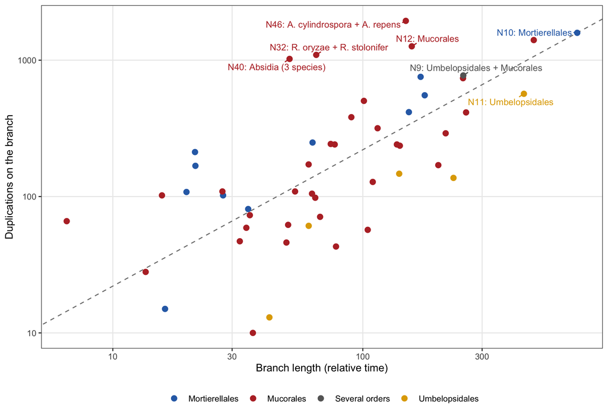

**Figure 9.** Gene-tree duplications (at least 50% support) on each internal branch of the species tree against the length of the branch in the dated tree (relative time units, root = 1,000; log scales). Dashed line: the median rate over all internal branches. Labelled: the branches where Corrochano et al. placed the WGD (N9, N12), the stems of the three orders, and the recent WGDs of Absidia and Rhizopus (positive controls).

```r
lab_nodes <- merge(internal, key_nodes, by = "node")
ggplot(internal[dups > 0], aes(brlen, dups, colour = clade_order)) +
  geom_abline(intercept = log10(med_rate), slope = 1, linetype = "dashed", colour = "grey50") +
  geom_point(size = 2.2) +
  geom_text_repel(data = lab_nodes, aes(label = paste0(node, ": ", label)), size = 3,
                  show.legend = FALSE, min.segment.length = 0, max.overlaps = 20) +
  scale_x_log10() + scale_y_log10() +
  scale_colour_manual(values = c(order_cols, "Several orders" = "grey40"), name = NULL) +
  labs(x = "Branch length (relative time)", y = "Duplications on the branch") +
  theme(legend.position = "bottom")
```

## 4.2 Collinearity of the duplicates

Each gene-tree duplication splits a gene family into two sets of copies. Within each descendant genome, all pairs of genes across the two sets were looked up among the doubletrouble pairs, to see which mode they were classified as. A WGD leaves many duplicates in collinear blocks, so a large share of segmental pairs among the duplicates of one branch is the collinearity signal of a WGD.

```r
fetch(sprintf("data/genomes/%1$s/%1$s_IDtbl.tsv", gen$genome))
alias_all <- rbindlist(lapply(gen$genome, function(g) {
  ids <- fread(sprintf("data/genomes/%1$s/%1$s_IDtbl.tsv", g))
  unique(rbind(ids[, .(id = proteinID, gene = geneID)], ids[, .(id = rnaID, gene = geneID)],
               ids[, .(id = geneID, gene = geneID)]))[, genome := g]
}))
# OrthoFinder writes genes as "<species>_<FASTA header>", with "." in the
# species name replaced by "_", separated by ", ". Pieces without a core-genome
# prefix are outgroup genes or parts of FASTA descriptions that contained ", ".
prefix <- data.table(genome = gen$genome, prefix = paste0(gsub(".", "_", of_names[gen$genome], fixed = TRUE), "_"))
sup_int <- sup[node %in% nodes[ntips > 1, node]]
sup_int[, event := .I]
gl <- rbind(sup_int[, .(event, node, side = 1L, x = genes1)], sup_int[, .(event, node, side = 2L, x = genes2)])
gl <- gl[, .(part = unlist(strsplit(x, ", ", fixed = TRUE))), by = .(event, node, side)]
gl[, genome := NA_character_]
for (i in seq_len(nrow(prefix))) gl[is.na(genome) & startsWith(part, prefix$prefix[i]), genome := prefix$genome[i]]
gl <- gl[!is.na(genome)]
gl[, id := sub(" .*", "", substring(part, nchar(prefix$prefix[match(genome, prefix$genome)]) + 1))]
gl <- merge(gl, alias_all, by = c("genome", "id"), all.x = TRUE)
gene_map_rate <- mean(!is.na(gl$gene))
gl <- gl[!is.na(gene)]

cross <- merge(gl[side == 1, .(event, node, genome, g1 = gene)], gl[side == 2, .(event, genome, g2 = gene)],
               by = c("event", "genome"), allow.cartesian = TRUE)
cross[, key := paste(pmin(g1, g2), pmax(g1, g2))]
cross <- unique(cross, by = c("genome", "key", "node"))
pair_key <- unique(pairs[, .(genome, key = paste(pmin(dup1, dup2), pmax(dup1, dup2)), type)], by = c("genome", "key"))
cross <- merge(cross, pair_key, by = c("genome", "key"), all.x = TRUE)
sd_node <- cross[, .(cross_pairs = .N, classified = sum(!is.na(type)), sd = sum(type == "SD", na.rm = TRUE)), by = node]
sd_node[, sd_share := sd / classified]
nodes <- merge(nodes, sd_node, by = "node", all.x = TRUE)
internal <- merge(internal, sd_node, by = "node", all.x = TRUE)
```

98.3% of the core-genome genes in the duplication records were matched to gene IDs.

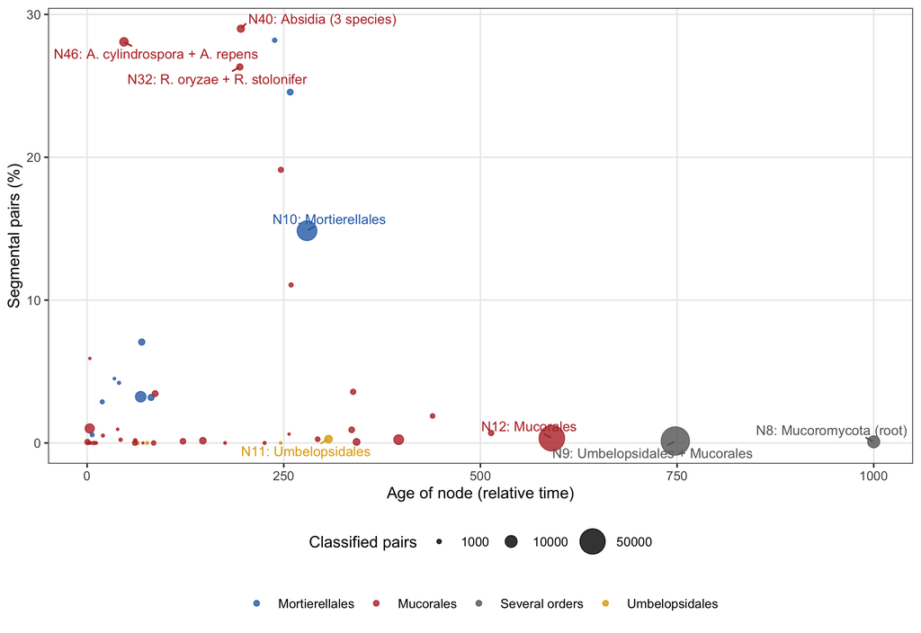

**Figure 10.** Percentage of segmental (SD) pairs among the doubletrouble pairs formed by the duplicates of each internal node, against the age of the node (relative time; root = 1,000). Only nodes with at least 100 classified pairs. Point size: number of classified pairs.

```r
sdp <- nodes[ntips > 1 & !is.na(age_end) & classified >= 100]
ggplot(sdp, aes(age_end, 100 * sd_share, colour = clade_order)) +
  geom_point(aes(size = classified), alpha = 0.8) +
  geom_text_repel(data = merge(sdp, key_nodes, by = "node"), aes(label = paste0(node, ": ", label)),
                  size = 3, show.legend = FALSE, min.segment.length = 0) +
  scale_colour_manual(values = c(order_cols, "Several orders" = "grey40"), name = NULL) +
  scale_size_area(max_size = 8, name = "Classified pairs", breaks = c(1000, 10000, 50000)) +
  labs(x = "Age of node (relative time)", y = "Segmental pairs (%)") +
  theme(legend.position = "bottom", legend.box = "vertical")
```

```r
node_tab <- merge(key_nodes, nodes, by = "node", sort = FALSE)
node_tab <- merge(node_tab, internal[, .(node, rate_rank)], by = "node", all.x = TRUE, sort = FALSE)
node_tab <- node_tab[, .(node, label, genomes = ntips,
                         branch = ifelse(is.na(brlen), "root", sprintf("%.0f-%.0f", age_start, age_end)),
                         duplications = dups, rate = round(rate, 1),
                         rate_rank = ifelse(is.na(rate_rank), "", sprintf("%d of %d", rate_rank, nrow(internal))),
                         SD_pct = round(100 * sd_share, 1), dups_per_family = round(per_og, 2),
                         single_pct = round(100 * single))]
knitr::kable(node_tab, caption = tcap("nodes", sprintf("Key branches. branch: start-end age (relative time). rate: duplications per time unit (median over internal branches %.1f); rate_rank: among %d internal branches of at least 5 time units. SD_pct: segmental pairs among classified duplicate pairs. dups_per_family: duplications per gene family duplicated on the branch; single_pct: families duplicated only once on the branch.", med_rate, nrow(internal))))
```

Table 8. Key branches. branch: start-end age (relative time). rate: duplications per time unit (median over internal branches 2.2); rate_rank: among 51 internal branches of at least 5 time units. SD_pct: segmental pairs among classified duplicate pairs. dups_per_family: duplications per gene family duplicated on the branch; single_pct: families duplicated only once on the branch.

| node | label | genomes | branch | duplications | rate | rate_rank | SD_pct | dups_per_family | single_pct |
| --- | --- | --- | --- | --- | --- | --- | --- | --- | --- |
| N8 | Mucoromycota (root) | 61 | root | 86 | NA |  | 0.1 | 1.21 | 83 |
| N9 | Umbelopsidales + Mucorales | 48 | 1000-748 | 773 | 3.1 | 19 of 51 | 0.1 | 1.32 | 78 |
| N12 | Mucorales | 42 | 748-591 | 1264 | 8.1 | 6 of 51 | 0.3 | 1.28 | 80 |
| N11 | Umbelopsidales | 6 | 748-307 | 567 | 1.3 | 38 of 51 | 0.3 | 1.18 | 87 |
| N10 | Mortierellales | 13 | 1000-280 | 1588 | 2.2 | 26 of 51 | 14.9 | 1.45 | 80 |
| N40 | Absidia (3 species) | 3 | 246-195 | 1022 | 20.1 | 1 of 51 | 29.0 | 1.18 | 85 |
| N46 | A. cylindrospora + A. repens | 2 | 195-47 | 1943 | 13.1 | 3 of 51 | 28.1 | 1.30 | 85 |
| N32 | R. oryzae + R. stolonifer | 2 | 259-194 | 1094 | 16.8 | 2 of 51 | 26.3 | 1.26 | 83 |

## 4.3 Macrosynteny between orders

The classical WGD test compares a duplicated genome with an unduplicated relative: each region of the relative should match two regions of the duplicated genome. This needs conserved synteny between the two. Chromosome pairs sharing more one-to-one orthologs than expected (hypergeometric test, BH-adjusted p < 0.05 and at least twice the expected number) were identified between Hi-C assemblies, with *R. microsporus* against *R. oryzae* as the control.

```r
load_alias <- function(g) alias_all[genome == g, .(id, gene)]
known_ids <- function(cell, known) {
  lapply(strsplit(cell, ", ", fixed = TRUE), function(p) { w <- sub(" .*", "", p); w[w %in% known] })
}
# All ortholog relations between two genomes, with positions and copy numbers
orthologs_pos <- function(a, b) {
  f <- sprintf("data/orthofinder/results/Orthologues/Orthologues_%1$s/%1$s__v__%2$s.tsv",
               of_names[[a]], of_names[[b]])
  fetch(f)
  o <- fread(f, sep = "\t", header = TRUE, quote = "", col.names = c("og", "a", "b"))
  o[, rel := .I]
  aa <- load_alias(a); ab <- load_alias(b)
  la <- o[, .(id = unlist(known_ids(a, aa$id))), by = rel][, gene := aa$gene[match(id, aa$id)]]
  lb <- o[, .(id = unlist(known_ids(b, ab$id))), by = rel][, gene := ab$gene[match(id, ab$id)]]
  la <- merge(la, gp[genome == a, .(gene = geneID, seq_a = seqname)], by = "gene")
  lb <- merge(lb, gp[genome == b, .(gene = geneID, seq_b = seqname)], by = "gene")
  la[, n_a := .N, by = rel]; lb[, n_b := .N, by = rel]
  merge(la[, .(rel, seq_a, n_a)], lb[, .(rel, seq_b, n_b)], by = "rel", allow.cartesian = TRUE)
}
macro_grid <- function(x, a, b) {
  big_a <- cl[genome == a & length >= 1e6, seqname]; big_b <- cl[genome == b & length >= 1e6, seqname]
  o1 <- x[n_a == 1 & n_b == 1 & seq_a %in% big_a & seq_b %in% big_b]
  total <- nrow(o1)
  g <- CJ(seq_a = unique(o1$seq_a), seq_b = unique(o1$seq_b))
  g <- merge(g, o1[, .N, by = .(seq_a, seq_b)], by = c("seq_a", "seq_b"), all.x = TRUE)
  g[is.na(N), N := 0L]
  g[, Na := sum(N), by = seq_a][, Nb := sum(N), by = seq_b]
  g[, `:=`(expected = Na * Nb / total, p = phyper(N - 1, Nb, total - Nb, Na, lower.tail = FALSE))]
  g[, padj := p.adjust(p, "BH")]
  g[, sig := padj < 0.05 & N >= 2 * expected]
  g[, `:=`(a = a, b = b, total = total)]
  g
}
macro_pairs <- data.table(a = c("gzRhiMicr1", "gzMucCirc1", "gzUmbVina1", "ggMorZona1"),
                          b = c("ggRhiOryz1", "ggRhiOryz1", "gzMucCirc1", "gzMucCirc1"))
macro_x <- lapply(seq_len(nrow(macro_pairs)), function(i) orthologs_pos(macro_pairs$a[i], macro_pairs$b[i]))
grids <- rbindlist(lapply(seq_len(nrow(macro_pairs)), function(i) macro_grid(macro_x[[i]], macro_pairs$a[i], macro_pairs$b[i])))
sp_short <- function(g) { s <- strsplit(gen$species[match(g, gen$genome)], " ")[[1]]; paste0(substr(s[1], 1, 1), ". ", s[2]) }
macro_tab <- grids[, .(one_to_one = total[1], in_linked_pct = round(100 * sum(N[sig]) / total[1], 1),
                       linked_pairs = sum(sig),
                       ref_chromosomes = uniqueN(seq_a[Na >= 50]),
                       median_partners = as.numeric(median(.SD[Na >= 50, sum(sig), by = seq_a]$V1))),
                   by = .(a, b)]
macro_tab[, comparison := paste(sp_short(a), "vs", sp_short(b)), by = .(a, b)]

# Control: do both R. oryzae copies of 1:2 orthologs fall on chromosomes
# linked to the R. microsporus chromosome?
ctrl <- grids[a == "gzRhiMicr1"]
linked <- ctrl[sig == TRUE, paste(seq_a, seq_b)]
big_b <- cl[genome == "ggRhiOryz1" & length >= 1e6, seqname]
r12 <- macro_x[[1]][n_a == 1 & n_b == 2 & seq_b %in% big_b][, if (.N == 2) .(both = all(paste(seq_a, seq_b) %in% linked)), by = rel]
ctrl_base <- sum(ctrl[sig == TRUE, N]) / ctrl$total[1]
knitr::kable(macro_tab[, .(comparison, a, b, one_to_one, linked_pairs, in_linked_pct, ref_chromosomes, median_partners)],
             caption = tcap("macro", "Macrosynteny between chromosome-level assemblies (sequences >= 1 Mb). linked_pairs: chromosome pairs with significantly more one-to-one orthologs than expected; in_linked_pct: percentage of one-to-one orthologs in those pairs; median_partners: median number of linked chromosomes of the second genome per chromosome of the first (chromosomes with at least 50 orthologs)."))
```

Table 9. Macrosynteny between chromosome-level assemblies (sequences >= 1 Mb). linked_pairs: chromosome pairs with significantly more one-to-one orthologs than expected; in_linked_pct: percentage of one-to-one orthologs in those pairs; median_partners: median number of linked chromosomes of the second genome per chromosome of the first (chromosomes with at least 50 orthologs).

| comparison | a | b | one_to_one | linked_pairs | in_linked_pct | ref_chromosomes | median_partners |
| --- | --- | --- | --- | --- | --- | --- | --- |
| R. microsporus vs R. oryzae | gzRhiMicr1 | ggRhiOryz1 | 5538 | 17 | 24.9 | 9 | 2 |
| M. circinelloides vs R. oryzae | gzMucCirc1 | ggRhiOryz1 | 5248 | 2 | 1.2 | 12 | 0 |
| U. vinacea vs M. circinelloides | gzUmbVina1 | gzMucCirc1 | 3837 | 0 | 0.0 | 12 | 0 |
| M. zonata vs M. circinelloides | ggMorZona1 | gzMucCirc1 | 2904 | 0 | 0.0 | 21 | 0 |

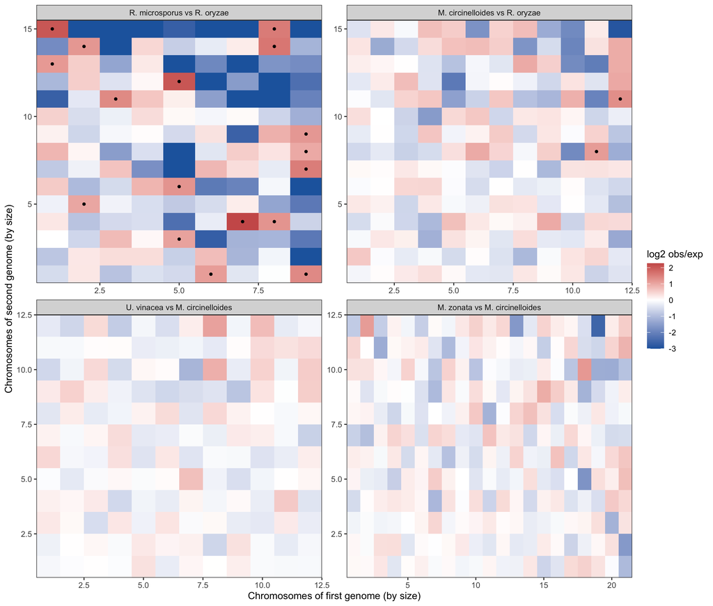

**Figure 11.** Oxford grids of one-to-one orthologs between chromosomes (sequences >= 1 Mb, ordered by size) of two genomes. Colour: log2 of observed over expected orthologs; dots: significantly linked chromosome pairs. Top left: R. microsporus against R. oryzae, which had a WGD after their split (control).

```r
grids[, `:=`(enrich = pmax(pmin(log2((N + 0.5) / (expected + 0.5)), 3), -3),
             panel = factor(paste(sp_short(a), "vs", sp_short(b)), macro_tab$comparison)), by = .(a, b)]
size_rank <- function(g, s) {  # rank of each chromosome by length (1 = largest)
  chroms <- cl[genome == g & seqname %in% s][order(-length), seqname]
  match(s, chroms)
}
grids[, `:=`(xa = size_rank(a[1], seq_a), yb = size_rank(b[1], seq_b)), by = .(a, b)]
ggplot(grids, aes(xa, yb, fill = enrich)) +
  geom_tile() +
  geom_point(data = grids[sig == TRUE], size = 1) +
  facet_wrap(~panel, scales = "free") +
  scale_fill_gradient2(low = "#2166AC", mid = "white", high = "#B2182B", name = "log2 obs/exp") +
  scale_x_continuous(expand = c(0, 0)) + scale_y_continuous(expand = c(0, 0)) +
  labs(x = "Chromosomes of first genome (by size)", y = "Chromosomes of second genome (by size)") +
  theme(panel.grid = element_blank())
```

## 4.4 Copy number in gene families

For each orthogroup, the median number of genes was taken over the genomes of each group. Orthogroups present in both groups were counted as 2:1 (median 2 in the first group, 1 in the second) or 1:2. Without duplication on either branch the two counts should be similar; a WGD in one group gives an excess of 2:1 families in that group (two-sided binomial test). The orthogroups were also checked for supported gene-tree duplications on the stems of Mucorales (N12), of Umbelopsidales + Mucorales (N9) and of Mortierellales (N10).

```r
cn <- melt(fread("data/orthofinder/results/Orthogroups/Orthogroups.GeneCount.tsv")[
  , c("Orthogroup", of_names[gen$genome]), with = FALSE], id.vars = "Orthogroup",
  variable.name = "of_name", value.name = "n")
cn[, genome := names(of_names)[match(of_name, of_names)]]
groups <- list(
  Mucorales = gen[order == "Mucorales", genome], Umbelopsidales = gen[order == "Umbelopsidales", genome],
  Mortierellales = gen[order == "Mortierellales", genome],
  "Absidia (A. cylindrospora, A. repens)" = c("gzAbsCyli1", "AbsRepe"),
  "Halteromyces + Cunninghamella" = c("HalRadi", "gzCunBlak1", "gzCunEchi1", "CunBert"),
  "Rhizopus (R. oryzae, R. stolonifer)" = c("ggRhiOryz1", "gzRhiStol1"),
  "R. microsporus" = c("gzRhiMicr1", "RhiMicr2"))
node_ogs <- function(nd) unique(sup[node == nd, og])
asym_test <- function(x, y) {
  m <- merge(cn[genome %in% groups[[x]], .(mx = median(n)), by = Orthogroup],
             cn[genome %in% groups[[y]], .(my = median(n)), by = Orthogroup], by = "Orthogroup")
  m <- m[mx >= 1 & my >= 1]
  r21 <- m[mx == 2 & my == 1, Orthogroup]; r12 <- m[mx == 1 & my == 2, Orthogroup]
  link <- function(ogs, nd) round(100 * mean(ogs %in% node_ogs(nd)))
  data.table(first = x, second = y, families = nrow(m), two_to_one = length(r21), one_to_two = length(r12),
             ratio = round(length(r21) / length(r12), 1),
             p = binom.test(length(r21), length(r21) + length(r12))$p.value,
             N12_in_2to1 = link(r21, "N12"), N9_in_2to1 = link(r21, "N9"), N10_in_1to2 = link(r12, "N10"))
}
asym <- rbindlist(list(
  asym_test("Absidia (A. cylindrospora, A. repens)", "Halteromyces + Cunninghamella"),
  asym_test("Rhizopus (R. oryzae, R. stolonifer)", "R. microsporus"),
  asym_test("Mucorales", "Umbelopsidales"), asym_test("Mucorales", "Mortierellales"),
  asym_test("Umbelopsidales", "Mortierellales")))
asym_show <- copy(asym)[, p := fmt_p(p)]
knitr::kable(asym_show, caption = tcap("asym", "Gene families with median copy number 2 in the first group and 1 in the second (two_to_one), and the reverse (one_to_two), among families present in both groups. The first two rows are the positive controls. N12_in_2to1, N9_in_2to1: percentage of the 2:1 families with a supported duplication on the Mucorales stem (N12) or the Umbelopsidales + Mucorales stem (N9); N10_in_1to2: percentage of the 1:2 families with a supported duplication on the Mortierellales stem (N10)."))
```

Table 10. Gene families with median copy number 2 in the first group and 1 in the second (two_to_one), and the reverse (one_to_two), among families present in both groups. The first two rows are the positive controls. N12_in_2to1, N9_in_2to1: percentage of the 2:1 families with a supported duplication on the Mucorales stem (N12) or the Umbelopsidales + Mucorales stem (N9); N10_in_1to2: percentage of the 1:2 families with a supported duplication on the Mortierellales stem (N10).

| first | second | families | two_to_one | one_to_two | ratio | p | N12_in_2to1 | N9_in_2to1 | N10_in_1to2 |
| --- | --- | --- | --- | --- | --- | --- | --- | --- | --- |
| Absidia (A. cylindrospora, A. repens) | Halteromyces + Cunninghamella | 6084 | 991 | 17 | 58.3 | 2.1e-267 | 9 | 2 | 18 |
| Rhizopus (R. oryzae, R. stolonifer) | R. microsporus | 5752 | 565 | 30 | 18.8 | 5e-129 | 9 | 4 | 17 |
| Mucorales | Umbelopsidales | 5652 | 673 | 133 | 5.1 | 1.3e-87 | 56 | 10 | 15 |
| Mucorales | Mortierellales | 4866 | 481 | 336 | 1.4 | 4.4e-07 | 45 | 22 | 60 |
| Umbelopsidales | Mortierellales | 4915 | 288 | 522 | 0.6 | 1.7e-16 | 29 | 42 | 62 |

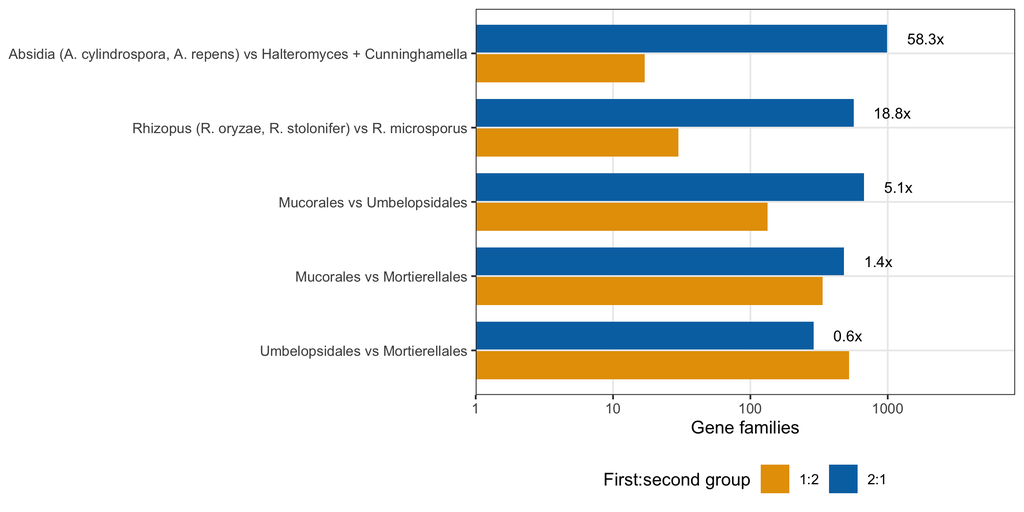

**Figure 12.** Number of gene families with median copy number 2:1 and 1:2 between two groups of genomes (log scale), with the ratio. The two recent WGDs (top) are positive controls.

```r
asym_long <- melt(asym[, .(cmp = paste(first, "vs", second), two_to_one, one_to_two, ratio)],
                  id.vars = c("cmp", "ratio"), variable.name = "pattern", value.name = "families")
asym_long[, `:=`(cmp = factor(cmp, rev(unique(cmp))),
                 pattern = factor(pattern, c("one_to_two", "two_to_one"), c("1:2", "2:1")))]
ggplot(asym_long, aes(families, cmp, fill = pattern)) +
  geom_col(position = position_dodge(width = 0.8), width = 0.75) +
  geom_text(data = asym_long[pattern == "2:1"], aes(x = families * 1.4, label = paste0(ratio, "x")),
            position = position_nudge(y = 0.2), size = 3, hjust = 0) +
  scale_x_log10(expand = expansion(mult = c(0, 0.25))) +
  scale_fill_manual(values = c("2:1" = "#0072B2", "1:2" = "#E69F00"), name = "First:second group") +
  labs(x = "Gene families", y = NULL) +
  theme(legend.position = "bottom")
```

## 4.5 The two *Absidia* branches: one WGD, partly rediploidized after a speciation

The *Absidia* duplications are split between the branch before *A. glauca* diverged (N40) and the branch after it (N46). Two rounds of genome-wide duplication within this short time are unlikely. After a WGD, the two copies of a region can keep recombining as one (tetrasomic inheritance) until the genome is rediploidized. If a speciation happens before that is complete, the copies of some regions start diverging before the split, and those of other regions only afterwards, independently in each daughter lineage. In gene trees, the first appear as duplications before the speciation (ancestral ohnolog resolution, AORe), the second as separate duplications in each lineage (lineage-specific ohnolog resolution, LORe), as after the salmonid WGD. This predicts that (1) *A. glauca* has both copies of the N40 duplications, (2) it is outside the N46 duplications but often has two copies of its own in the same families, forming a duplication on the *A. glauca* branch, and (3) N46 pairs are younger than N40 pairs.

```r
gl_pre <- paste0(gsub(".", "_", of_names[["gzAbsGlau1"]], fixed = TRUE), "_")
has_gla <- function(x) vapply(strsplit(x, ", ", fixed = TRUE), function(v) any(startsWith(v, gl_pre)), FALSE)
abs_ev <- sup[node %in% c("N40", "N46")]
abs_ev[, `:=`(s1 = has_gla(genes1), s2 = has_gla(genes2))]
pair_ks_all <- unique(pairs[near_ident == FALSE, .(genome, key = paste(pmin(dup1, dup2), pmax(dup1, dup2)), Ks)],
                      by = c("genome", "key"))
abs_ks <- merge(cross[node %in% c("N40", "N46"), .(genome, key, node)], pair_ks_all, by = c("genome", "key"))[
  Ks <= 5, .(pairs_with_Ks = .N, median_Ks = round(median(Ks), 2)), by = node]
abs_tab <- abs_ev[, .(duplications = .N, glauca_both = round(100 * mean(s1 & s2)),
                      glauca_one = round(100 * mean(xor(s1, s2))), glauca_absent = round(100 * mean(!s1 & !s2))),
                  by = node]
abs_tab <- merge(merge(key_nodes, abs_tab, by = "node"), abs_ks, by = "node")[order(node == "N46")]
knitr::kable(abs_tab, caption = tcap("absidia", "Supported gene-tree duplications on the two Absidia branches: percentage in which A. glauca has genes on both sides of the duplication (both copies), on one side, or on neither (A. glauca outside the duplicated subtree), and the median Ks of the duplicate pairs in A. cylindrospora and A. repens (and A. glauca for N40)."))
```

Table 11. Supported gene-tree duplications on the two Absidia branches: percentage in which A. glauca has genes on both sides of the duplication (both copies), on one side, or on neither (A. glauca outside the duplicated subtree), and the median Ks of the duplicate pairs in A. cylindrospora and A. repens (and A. glauca for N40).

| node | label | duplications | glauca_both | glauca_one | glauca_absent | pairs_with_Ks | median_Ks |
| --- | --- | --- | --- | --- | --- | --- | --- |
| N40 | Absidia (3 species) | 1022 | 92 | 8 | 0 | 3144 | 1.92 |
| N46 | A. cylindrospora + A. repens | 1943 | 0 | 0 | 100 | 4661 | 1.68 |

```r
# Families duplicated only on N46: A. glauca copy number, and whether A. glauca's
# copies form their own (terminal) duplication in the gene tree
gla_term <- unique(dups[node == "gzAbsGlau1", og])
only46 <- setdiff(abs_ev[node == "N46", og], abs_ev[node == "N40", og])
gla_n <- cn[genome == "gzAbsGlau1", .(og = Orthogroup, gla = n)]
hal_n <- cn[genome == "HalRadi", .(og = Orthogroup, hal = n)]
lore <- merge(data.table(og = only46), gla_n, by = "og")
bg <- merge(gla_n[gla >= 2], hal_n[hal >= 1], by = "og")[!og %in% abs_ev$og]
lore_s <- list(n = nrow(lore), multi = lore[gla >= 2, .N], single = lore[gla == 1, .N],
               term = 100 * lore[gla >= 2, mean(og %in% gla_term)], bg_term = 100 * mean(bg$og %in% gla_term))
abs_genes <- gen[genome %in% c("gzAbsGlau1", "gzAbsCyli1", "AbsRepe"), .(genome, genes, busco = qc$Busco[match(genome, qc$genome_id)])]
```

```r
at <- function(nd, col) abs_tab[node == nd][[col]]
```

- **Shared before the split.** *A. glauca* has both copies of 92% of the 1,022 N40 duplications (Table 11): these are duplications shared by all three species.
- **Resolved after the split.** *A. glauca* lies outside 100% of the 1,943 N46 duplications. In 798 of the 1,275 families duplicated only on N46, *A. glauca* nevertheless has two or more copies, and in 68% of these its copies form their own duplication on the *A. glauca* branch (48% in other families where *A. glauca* has several copies). The same ancestral duplication thus appears as two lineage-specific duplications.
- **Younger pairs after the split.** The N46 pairs have a median Ks of 1.68, against 1.92 for the N40 pairs, as expected if they started diverging later. Each genome has a single segmental Ks peak (Table 6), not two.
- **Gene loss in *A. glauca*.** In 455 N46-only families *A. glauca* has a single copy. It has fewer genes (12,838, against 14,915 and 15,695) and a less complete annotation (BUSCO 87.9%, against 97% for *A. cylindrospora*), which also explains its smaller number of segmental pairs.
- **Conclusion.** One WGD in the *Absidia* ancestor, before *A. glauca* diverged, with rediploidization completed for part of the genome only after the split (LORe), and more gene loss or missing annotation in *A. glauca*, explains the two-branch signal without a second round of duplication. The species tree is not in doubt: *A. cylindrospora* and *A. repens* are close (ortholog Ks 0.26) and *A. glauca* clearly outside (2.25).

## 4.6 Conclusion

```r
nv <- function(nd, col) nodes[node == nd][[col]]
ir <- function(nd) internal[node == nd, rate_rank]
ctrl_sd <- range(nodes[node %in% c("N40", "N46", "N32"), sd_share])
ctrl_rate <- range(nodes[node %in% c("N40", "N46", "N32"), rate])
ctrl_per_og <- range(nodes[node %in% c("N40", "N46", "N32"), per_og])
ctrl_age <- range(nodes[node %in% c("N40", "N46", "N32"), c(age_start, age_end)])
above <- internal[rate > nv("N12", "rate") & !node %in% c("N40", "N46", "N32")]
mort_early <- nodes[node %in% c("N10", "N13", "N19"), range(sd_share)]
mort_late <- nodes[clade_order == "Mortierellales" & ntips > 1 & age_end < 100 & classified >= 100, range(sd_share)]
a <- function(f, s, col) asym[first == f & second == s][[col]]
mt <- function(a_, col) macro_tab[a == a_][[col]]
conc_nodes <- internal[dups >= 500][order(-per_og)][1:2]
```

# 5 Copy number with microsynteny

A WGD adds copies to many gene families at once, in collinear blocks (segmental duplicates while gene order is conserved, dispersed duplicates once it has eroded). Small-scale duplication adds copies family by family, often next to the original (tandem or proximal duplicates) or by transposition (dispersed). Two views:

1. **Expanded families:** for gene families with more copies in a clade than in its sister group, what modes do the clade’s genes have, compared with genes of families that are not expanded?
2. **Duplicates per branch:** what is the mix of modes among the duplicates that the gene trees place on each key branch (Section 4.2)?

```r
fetch("data/orthofinder/results/Orthogroups/Orthogroups.tsv")
og_tab <- fread("data/orthofinder/results/Orthogroups/Orthogroups.tsv", sep = "\t", quote = "")
# Genes of each core genome per orthogroup (cells list FASTA headers, ", "-separated)
og_genes <- rbindlist(lapply(gen$genome, function(g) {
  cell <- og_tab[[of_names[[g]]]]
  keep <- cell != ""
  l <- data.table(og = og_tab$Orthogroup[keep], cell = cell[keep])[
    , .(id = sub(" .*", "", unlist(strsplit(cell, ", ", fixed = TRUE)))), by = og]
  a <- alias_all[genome == g]
  unique(l[id %in% a$id][, .(og, genome = g, gene = a$gene[match(id, a$id)])])
}))
og_genes <- merge(og_genes, gmode, by = c("genome", "gene"), all.x = TRUE)
og_genes[is.na(mode), mode := "Not duplicated"]
dup_in_og <- mean(paste(gmode$genome, gmode$gene) %in% paste(og_genes$genome, og_genes$gene))
```

## 5.1 Modes of genes in expanded families

A family is expanded in a clade if its median copy number there is at least 2 and at least one more than in the sister group; families present in both with an equal or lower median in the clade are the background. Copy numbers are the medians of Section 4.4. The genes of the clade’s genomes in each set were classified by their duplication mode (Section 2). 98.0% of the duplicated genes are in an orthogroup.

```r
exp_cmp <- data.table(
  x = c("Absidia (A. cylindrospora, A. repens)", "Rhizopus (R. oryzae, R. stolonifer)",
        "Mucorales", "Mucorales", "Mortierellales"),
  y = c("Halteromyces + Cunninghamella", "R. microsporus", "Umbelopsidales", "Mortierellales",
        "Umbelopsidales"))
group_median <- function(gs) cn[genome %in% gs, .(m = median(n)), by = Orthogroup]
mode_levels_all <- c(mode_levels, "Not duplicated")
exp_modes <- rbindlist(lapply(seq_len(nrow(exp_cmp)), function(i) {
  x <- exp_cmp$x[i]; y <- exp_cmp$y[i]
  m <- merge(group_median(groups[[x]]), group_median(groups[[y]]), by = "Orthogroup", suffixes = c("x", "y"))
  m <- m[mx >= 1 & my >= 1]
  sets <- list(Expanded = m[mx >= 2 & mx >= my + 1, Orthogroup], Background = m[mx <= my, Orthogroup])
  if (x == "Mucorales" && y == "Umbelopsidales") {
    sets[["Expanded, with N12 duplication"]] <- intersect(sets$Expanded, node_ogs("N12"))
  }
  rbindlist(lapply(names(sets), function(s) {
    g <- og_genes[genome %in% groups[[x]] & og %in% sets[[s]]]
    g[, .N, by = mode][, `:=`(comparison = paste(x, "vs", y), set = s, families = length(sets[[s]]),
                              genes = nrow(g), pct = 100 * N / nrow(g))]
  }))
}))
exp_wide <- dcast(exp_modes, comparison + set + families + genes ~ mode, value.var = "pct", fill = 0)
for (m in mode_levels_all) if (!m %in% names(exp_wide)) exp_wide[, (m) := 0]
exp_wide[, `:=`(local = TD + PD)]
exp_wide <- exp_wide[order(match(comparison, unique(exp_modes$comparison)), match(set, c("Background", "Expanded", "Expanded, with N12 duplication")))]
exp_show <- exp_wide[, .(comparison, set, families, genes, SD = round(SD, 1), `TD + PD` = round(local, 1),
                         DD = round(DD, 1), `Near-identical` = round(`Near-identical`, 1),
                         `Not duplicated` = round(`Not duplicated`, 1))]
knitr::kable(exp_show, caption = tcap("exp_modes", "Duplication modes (% of genes) of the clade's genes in gene families expanded in the clade relative to its sister group, and in background families. Each gene counted once (priority SD > TD > PD > DD; near-identical only for genes in no older pair). The first two comparisons are the positive controls."))
```

Table 12. Duplication modes (% of genes) of the clade’s genes in gene families expanded in the clade relative to its sister group, and in background families. Each gene counted once (priority SD > TD > PD > DD; near-identical only for genes in no older pair). The first two comparisons are the positive controls.

| comparison | set | families | genes | SD | TD + PD | DD | Near-identical | Not duplicated |
| --- | --- | --- | --- | --- | --- | --- | --- | --- |
| Absidia (A. cylindrospora, A. repens) vs Halteromyces + Cunninghamella | Background | 3115 | 7265 | 1.8 | 0.8 | 34.9 | 0.3 | 62.1 |
| Absidia (A. cylindrospora, A. repens) vs Halteromyces + Cunninghamella | Expanded | 2352 | 17156 | 29.7 | 3.8 | 60.5 | 0.8 | 5.2 |
| Rhizopus (R. oryzae, R. stolonifer) vs R. microsporus | Background | 3217 | 7934 | 1.8 | 0.6 | 41.2 | 0.4 | 56.0 |
| Rhizopus (R. oryzae, R. stolonifer) vs R. microsporus | Expanded | 1496 | 12169 | 19.2 | 2.9 | 70.1 | 0.9 | 6.9 |
| Mucorales vs Umbelopsidales | Background | 4307 | 219110 | 2.1 | 1.5 | 43.9 | 1.3 | 51.2 |
| Mucorales vs Umbelopsidales | Expanded | 1270 | 162796 | 3.4 | 3.8 | 83.5 | 1.0 | 8.4 |
| Mucorales vs Umbelopsidales | Expanded, with N12 duplication | 760 | 105635 | 3.4 | 3.9 | 85.4 | 0.4 | 6.9 |
| Mucorales vs Mortierellales | Background | 3847 | 201196 | 2.1 | 1.4 | 45.7 | 1.3 | 49.4 |
| Mucorales vs Mortierellales | Expanded | 992 | 128518 | 3.4 | 2.6 | 86.3 | 0.8 | 6.9 |
| Mortierellales vs Umbelopsidales | Background | 4110 | 63592 | 7.6 | 1.5 | 37.4 | 0.8 | 52.6 |
| Mortierellales vs Umbelopsidales | Expanded | 773 | 32544 | 21.8 | 12.9 | 58.3 | 0.5 | 6.5 |

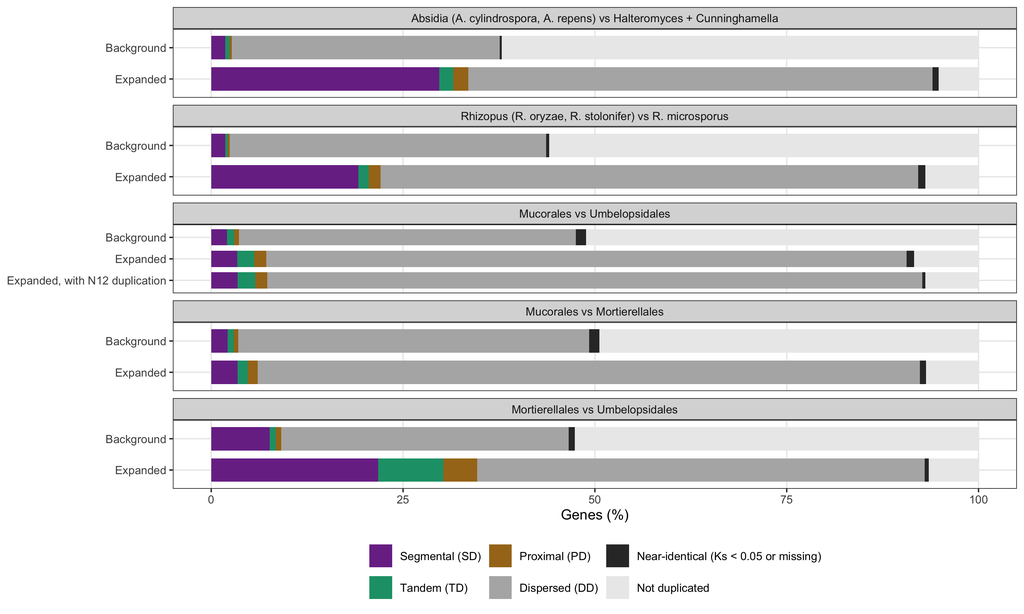

**Figure 13.** Duplication modes of genes in gene families expanded in a clade relative to its sister group (Expanded) and in families that are not (Background), for the two recent WGDs (positive controls, top) and the comparisons between orders.

```r
em <- copy(exp_modes)
em[, `:=`(mode = factor(mode, rev(mode_levels_all)),
          set = factor(set, rev(c("Background", "Expanded", "Expanded, with N12 duplication"))),
          comparison = factor(comparison, unique(exp_modes$comparison)))]
ggplot(em, aes(pct, set, fill = mode)) +
  geom_col(width = 0.75) +
  facet_wrap(~comparison, ncol = 1, strip.position = "top", scales = "free_y") +
  scale_fill_manual(values = c(mode_cols, "Not duplicated" = "grey92"), breaks = mode_levels_all,
                    labels = c(mode_labs, "Not duplicated" = "Not duplicated"), name = NULL) +
  labs(x = "Genes (%)", y = NULL) +
  theme(legend.position = "bottom", strip.text = element_text(size = 8)) +
  guides(fill = guide_legend(nrow = 2))
```

## 5.2 Modes of the duplicates of each branch

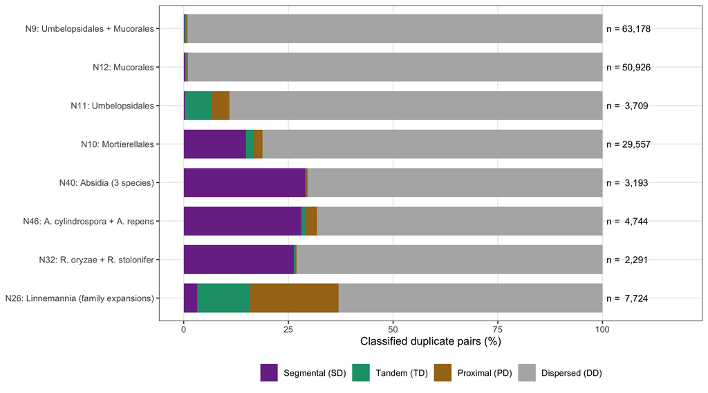

**Figure 14.** Duplication modes of the doubletrouble pairs formed by the duplicates of each key branch (Section 4.2). The branches with the recent WGDs (N40, N46, N32) are positive controls; N26 (Linnemannia, a burst concentrated in few gene families, Section 4) is shown for comparison. n: classified pairs.

```r
nm_nodes <- rbind(key_nodes[node != "N8"], data.table(node = "N26", label = "Linnemannia (family expansions)"))
nm <- cross[node %in% nm_nodes$node & !is.na(type), .N, by = .(node, type)]
nm[, pct := 100 * N / sum(N), by = node]
nm <- merge(nm, nm_nodes, by = "node")
nm_n <- nm[, .(n = sum(N)), by = .(node, label)]
nm[, lab := factor(paste0(node, ": ", label), rev(paste0(nm_nodes$node, ": ", nm_nodes$label)))]
nm_n[, lab := factor(paste0(node, ": ", label), levels(nm$lab))]
nm[, type := factor(type, rev(c("SD", "TD", "PD", "DD")))]
ggplot(nm, aes(pct, lab, fill = type)) +
  geom_col(width = 0.75) +
  geom_text(data = nm_n, aes(x = 101, y = lab, label = paste0("n = ", format(n, big.mark = ","))),
            inherit.aes = FALSE, hjust = 0, size = 3) +
  scale_fill_manual(values = mode_cols, breaks = c("SD", "TD", "PD", "DD"),
                    labels = mode_labs[c("SD", "TD", "PD", "DD")], name = NULL) +
  scale_x_continuous(limits = c(0, 118), breaks = c(0, 25, 50, 75, 100)) +
  labs(x = "Classified duplicate pairs (%)", y = NULL) +
  theme(legend.position = "bottom")
```

```r
node_modes <- dcast(nm, node ~ type, value.var = "pct", fill = 0)
```

## 5.3 Conclusion

```r
ew <- function(cmp, s, col) exp_wide[comparison == cmp & set == s][[col]]
c_abs <- "Absidia (A. cylindrospora, A. repens) vs Halteromyces + Cunninghamella"
c_rhi <- "Rhizopus (R. oryzae, R. stolonifer) vs R. microsporus"
c_mu <- "Mucorales vs Umbelopsidales"; c_mm <- "Mucorales vs Mortierellales"; c_mo <- "Mortierellales vs Umbelopsidales"
f1 <- function(v) sprintf("%.1f", v)
nmod <- function(nd, ty) round(node_modes[node == nd][[ty]], 1)
```

- **Controls.** In families expanded in *Absidia* and *Rhizopus*, 29.7% and 19.2% of the genes are segmental duplicates, against 1.8% and 1.8% in background families, while tandem and proximal duplicates stay below 3.8% (Table 12, Figure 13): expansions by WGD, still in collinear blocks.
- **Mucorales expansions are dispersed.** Of the genes in families expanded in Mucorales relative to Umbelopsidales, 83.5% are dispersed duplicates, only 3.4% segmental and 3.8% tandem or proximal (similar for Mucorales against Mortierellales). For the expanded families with a duplication on the Mucorales stem the figures are 85.4%, 3.4% and 3.9%, and the duplicates mapped to N12 itself are 99% dispersed and 0.7% tandem or proximal (Figure 14), whereas the duplicates of the *Linnemannia* burst of family expansions (N26) are 33.7% tandem or proximal. The extra Mucorales copies are thus not the product of local tandem expansions; they are scattered across the genome, which is what an old WGD looks like after gene order has been scrambled, but also what dispersed (e.g. transposition-mediated) duplication produces.
- **Mortierellales expansions are collinear.** Families expanded in Mortierellales relative to Umbelopsidales are 21.8% segmental (background 7.6%) and 12.9% tandem or proximal, and the duplicates of the Mortierellales stem (N10) are 14.9% segmental. This supports a large-scale duplication early in Mortierellales (Section 4), with some tandem expansion on top.
- **Microsynteny therefore cannot separate the two explanations for the Mucorales stem burst.** Its duplicates look like those of a WGD whose blocks have eroded, and unlike tandem family expansions, but dispersed small-scale duplication would look the same, as long as segmental duplicates are defined by collinearity. Section 6 uses a definition that tolerates scrambled gene order.

# 6 Order-free synteny of duplicates

doubletrouble calls a pair segmental only if it is an anchor of a collinear block: at least 5 paralog pairs in the same order, with gaps of at most 25 genes. Gene order within chromosomes is scrambled much faster in Mucorales and Umbelopsidales than in Mortierellales (synteny analysis), which breaks blocks into pieces too short for this rule even when the duplicated regions still share their gene content. A duplicate pair that arose in a segmental duplication or WGD is then classified as dispersed. If so, the same ancestral duplication can be segmental in one genome and dispersed in another.

**Neighbourhood synteny.** For each paralog pair (A, B), the genes within W genes of A and of B were compared, ignoring order and orientation. The support of the pair is the number of different gene families (orthogroups, other than the family of A and B) with a paralog pair linking a gene near A to a gene near B. A pair is *neighbourhood-syntenic* if its support reaches a threshold k, i.e. A and B lie in regions that were duplicated together with genes of at least k other families. Near-identical pairs were excluded as pairs and as support, and pairs whose neighbourhoods overlap (closer than 2W genes on one sequence) were not tested. The rate expected by chance was measured by repeating the test after shuffling gene order in each genome (3 shuffles). The main setting is W = 10, k = 2; W = 20, k = 3 and W = 30, k = 4 have similar chance rates and are used to check robustness. Figure 15 illustrates the definition.

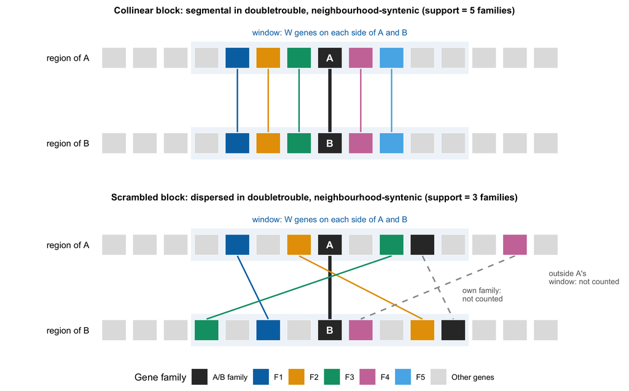

**Figure 15.** The neighbourhood synteny test for one paralog pair (A, B), drawn with a window of W = 4 genes (W = 10 in the analysis). Boxes: genes along the two regions, coloured by gene family; shaded: the window of W genes on each side of A and of B. Lines: paralog pairs. A link counts as support if it joins a gene in A’s window to a gene in B’s window and belongs to another family than A and B. Top: a collinear block, segmental by doubletrouble’s rule (at least 5 pairs in the same order) and neighbourhood-syntenic. Bottom: the same kind of duplicated region after gene order has been scrambled; too few pairs remain in order for doubletrouble, which calls A-B dispersed, but three families still link the two windows, so A-B is neighbourhood-syntenic (k = 2). Links of A’s own family and links to genes outside a window are not counted.

```r
W_demo <- 4; ctr <- 8; n_pos <- 15
p_col <- "Collinear block: segmental in doubletrouble, neighbourhood-syntenic (support = 5 families)"
p_scr <- "Scrambled block: dispersed in doubletrouble, neighbourhood-syntenic (support = 3 families)"
row_genes <- function(fams) {
  f <- rep("Other genes", n_pos)
  for (p in names(fams)) f[as.integer(p)] <- fams[[p]]
  f
}
sch_genes <- rbind(
  data.table(panel = p_col, row = "A", pos = 1:n_pos,
             fam = row_genes(list(`5` = "F1", `6` = "F2", `7` = "F3", `8` = "A/B family", `9` = "F4", `10` = "F5"))),
  data.table(panel = p_col, row = "B", pos = 1:n_pos,
             fam = row_genes(list(`5` = "F1", `6` = "F2", `7` = "F3", `8` = "A/B family", `9` = "F4", `10` = "F5"))),
  data.table(panel = p_scr, row = "A", pos = 1:n_pos,
             fam = row_genes(list(`5` = "F1", `7` = "F2", `8` = "A/B family", `10` = "F3", `11` = "A/B family", `14` = "F4"))),
  data.table(panel = p_scr, row = "B", pos = 1:n_pos,
             fam = row_genes(list(`4` = "F3", `6` = "F1", `8` = "A/B family", `9` = "F4", `11` = "F2", `12` = "A/B family"))))
sch_links <- rbind(
  data.table(panel = p_col, from = c(8, 5, 6, 7, 9, 10), to = c(8, 5, 6, 7, 9, 10),
             kind = c("Focal pair A-B", rep("Supporting link", 5)), fam = c("A/B family", "F1", "F2", "F3", "F4", "F5")),
  data.table(panel = p_scr, from = c(8, 5, 7, 10, 11, 14), to = c(8, 6, 11, 4, 12, 9),
             kind = c("Focal pair A-B", rep("Supporting link", 3), "Not counted", "Not counted"),
             fam = c("A/B family", "F1", "F2", "F3", "A/B family", "F4")))
sch_links[, link_col := fifelse(kind == "Supporting link", fam, kind)]
sch_genes[, y := fifelse(row == "A", 1, 0)]
sch_genes[, label := fifelse(fam == "A/B family" & pos == ctr, row, "")]
fam_fill <- c("A/B family" = "grey20", F1 = "#0072B2", F2 = "#E69F00", F3 = "#009E73",
              F4 = "#CC79A7", F5 = "#56B4E9", "Other genes" = "grey88")
link_cols <- c(fam_fill[c("F1", "F2", "F3", "F4", "F5")], "Focal pair A-B" = "grey20", "Not counted" = "grey60")
panels <- factor(c(p_col, p_scr), c(p_col, p_scr))
sch_genes[, panel := factor(panel, levels(panels))]
sch_links[, panel := factor(panel, levels(panels))]
win <- CJ(panel = panels, y = c(0, 1))
notes <- data.table(panel = factor(p_scr, levels(panels)), x = c(12.3, 15.1), y = c(0.42, 0.62),
                    label = c("own family:\nnot counted", "outside A's\nwindow: not counted"))
ggplot() +
  geom_rect(data = win, aes(xmin = ctr - W_demo - 0.5, xmax = ctr + W_demo + 0.5, ymin = y - 0.19, ymax = y + 0.19),
            fill = "#0072B2", alpha = 0.08) +
  geom_segment(data = sch_links, aes(x = from, xend = to, y = 0.87, yend = 0.13, colour = link_col,
                                     linetype = kind == "Not counted", linewidth = kind == "Focal pair A-B")) +
  geom_tile(data = sch_genes, aes(pos, y, fill = fam), width = 0.78, height = 0.24, colour = "white") +
  geom_text(data = sch_genes, aes(pos, y, label = label), colour = "white", fontface = "bold", size = 3.6) +
  geom_text(data = notes, aes(x, y, label = label), size = 2.8, colour = "grey40", hjust = 0, lineheight = 0.9) +
  geom_text(data = CJ(panel = panels, y = c(1, 0))[, label := fifelse(y == 1, "region of A", "region of B")],
            aes(x = 0.2, y = y, label = label), hjust = 1, size = 3.2) +
  geom_text(data = data.table(panel = panels), aes(x = ctr, y = 1.3), label = "window: W genes on each side of A and B",
            size = 3, colour = "#0072B2") +
  facet_wrap(~panel, ncol = 1) +
  scale_fill_manual(values = fam_fill, breaks = names(fam_fill), name = "Gene family") +
  scale_colour_manual(values = link_cols, guide = "none") +
  scale_linetype_manual(values = c(`FALSE` = "solid", `TRUE` = "dashed"), guide = "none") +
  scale_linewidth_manual(values = c(`FALSE` = 0.7, `TRUE` = 1.6), guide = "none") +
  coord_cartesian(xlim = c(-1.6, 16.6), ylim = c(-0.3, 1.38), clip = "off") +
  theme_void(base_size = 10) +
  theme(legend.position = "bottom", strip.text = element_text(size = 9.5, face = "bold", margin = margin(b = 4)),
        panel.spacing = unit(1.2, "lines"), plot.margin = margin(6, 6, 6, 6)) +
  guides(fill = guide_legend(nrow = 1))
```

```r
nb_path <- "data/genome_duplication/neighbourhood_support.tsv.gz"
nb_k <- c(`10` = 2, `20` = 3, `30` = 4)
if (!file.exists(nb_path)) {
  nbhd_support <- function(pp, ord, fam, W) {
    pp <- merge(pp, ord[, .(a = gene, sa = seq, ra = rank)], by = "a")
    pp <- merge(pp, ord[, .(b = gene, sb = seq, rb = rank)], by = "b")
    pp[, `:=`(fam_ab = fam[a], tested = !(sa == sb & abs(ra - rb) <= 2 * W))]
    links <- rbind(pp[, .(x = a, y = b, sx = sa, rx = ra, sy = sb, ry = rb)],
                   pp[, .(x = b, y = a, sx = sb, rx = rb, sy = sa, ry = ra)])
    links[, fam_xy := fam[x]]
    foc <- pp[tested == TRUE, .(a, b, sa, sb, fam_ab, alo = ra - W, ahi = ra + W, blo = rb - W, bhi = rb + W)]
    j <- links[foc, on = .(sx == sa, rx >= alo, rx <= ahi, sy == sb, ry >= blo, ry <= bhi),
               nomatch = NULL, allow.cartesian = TRUE, .(a = i.a, b = i.b, x, y, fam_xy, fam_ab = i.fam_ab)]
    j <- j[x != a & y != b & x != b & y != a & (is.na(fam_xy) | is.na(fam_ab) | fam_xy != fam_ab)]
    j[is.na(fam_xy), fam_xy := paste0("gene:", pmin(x, y))]
    s <- j[, .(support = uniqueN(fam_xy)), by = .(a, b)]
    out <- merge(pp[tested == TRUE, .(a, b)], s, by = c("a", "b"), all.x = TRUE)
    out[is.na(support), support := 0L]
    out
  }
  nb <- rbindlist(lapply(gen$genome, function(g) {
    pp <- pairs[genome == g & !near_ident, .(a = dup1, b = dup2)]
    ord <- unique(gp[genome == g, .(gene = geneID, seq = seqname, start)], by = "gene")
    setorder(ord, seq, start)
    ord[, rank := seq_len(.N), by = seq]
    fam <- og_genes[genome == g, setNames(og, gene)]
    rbindlist(lapply(as.numeric(names(nb_k)), function(W) {
      runs <- list(real = ord)
      for (s in 1:3) { set.seed(s); o <- copy(ord); o[, gene := sample(gene)]; runs[[paste0("null", s)]] <- o }
      rbindlist(lapply(names(runs), function(r) nbhd_support(pp, runs[[r]], fam, W)[, `:=`(W = W, run = r)]))
    }))[, genome := g]
  }))
  fwrite(nb, nb_path, sep = "\t")
}
nb <- fread(nb_path)
nb[, `:=`(key = paste(pmin(a, b), pmax(a, b)), pass = support >= nb_k[as.character(W)], is_null = run != "real")]
nb <- merge(nb, pair_key, by = c("genome", "key"), all.x = TRUE)
nb <- merge(nb, gen[, .(genome, order)], by = "genome")
```

## 6.1 Calibration

```r
calib <- nb[, .(chance = 100 * mean(pass[is_null]), real = 100 * mean(pass[!is_null]),
                SD = 100 * mean(pass[!is_null & type == "SD"]), DD = 100 * mean(pass[!is_null & type == "DD"])),
            by = .(W, k = nb_k[as.character(W)], order)][order(W, order)]
calib[, DD_over_chance := DD / chance]
num <- c("chance", "real", "SD", "DD", "DD_over_chance")
calib_show <- copy(calib)[, (num) := lapply(.SD, function(v) signif(v, 3)), .SDcols = num]
knitr::kable(calib_show, caption = tcap("nb_calib", "Percentage of tested paralog pairs that are neighbourhood-syntenic, by setting (window W, threshold k) and order: in genomes with shuffled gene order (chance), in the real genomes (real), and among doubletrouble's segmental (SD) and dispersed (DD) pairs. DD_over_chance: dispersed pairs passing relative to chance."))
```

Table 13. Percentage of tested paralog pairs that are neighbourhood-syntenic, by setting (window W, threshold k) and order: in genomes with shuffled gene order (chance), in the real genomes (real), and among doubletrouble’s segmental (SD) and dispersed (DD) pairs. DD_over_chance: dispersed pairs passing relative to chance.

| W | k | order | chance | real | SD | DD | DD_over_chance |
| --- | --- | --- | --- | --- | --- | --- | --- |
| 10 | 2 | Mortierellales | 0.161 | 10.50 | 77.0 | 6.31 | 39.30 |
| 10 | 2 | Umbelopsidales | 0.141 | 1.56 | 44.7 | 1.51 | 10.70 |
| 10 | 2 | Mucorales | 0.158 | 4.77 | 89.3 | 3.70 | 23.50 |
| 20 | 3 | Mortierellales | 0.174 | 12.30 | 90.2 | 7.31 | 42.10 |
| 20 | 3 | Umbelopsidales | 0.219 | 1.56 | 68.1 | 1.49 | 6.80 |
| 20 | 3 | Mucorales | 0.186 | 3.79 | 92.0 | 2.68 | 14.40 |
| 30 | 4 | Mortierellales | 0.198 | 13.40 | 95.4 | 8.13 | 41.00 |
| 30 | 4 | Umbelopsidales | 0.245 | 1.47 | 74.5 | 1.39 | 5.64 |
| 30 | 4 | Mucorales | 0.210 | 3.42 | 95.3 | 2.26 | 10.80 |

## 6.2 Neighbourhood synteny of the duplicates of each branch

```r
nbx <- merge(cross[, .(genome, key, node, event)], nb[, .(genome, key, W, run, is_null, pass)],
             by = c("genome", "key"))
nb_node <- nbx[, .(tested = sum(!is_null) / 1, real = 100 * mean(pass[!is_null]), chance = 100 * mean(pass[is_null])),
               by = .(node, W)]
nb_node[, tested := tested]
nb_ev <- nbx[W == 10, .(any = any(pass)), by = .(node, event, run)][
  , .(events = sum(run == "real"), ev_real = 100 * mean(any[run == "real"]), ev_chance = 100 * mean(any[run != "real"])), by = node]
nb_w <- dcast(nb_node, node ~ W, value.var = c("real", "chance", "tested"))
nb_w <- merge(nb_w, nb_ev, by = "node")
nb_w <- merge(nb_w, nodes[, .(node, ntips, clade_order, age_start, age_end)], by = "node")
```

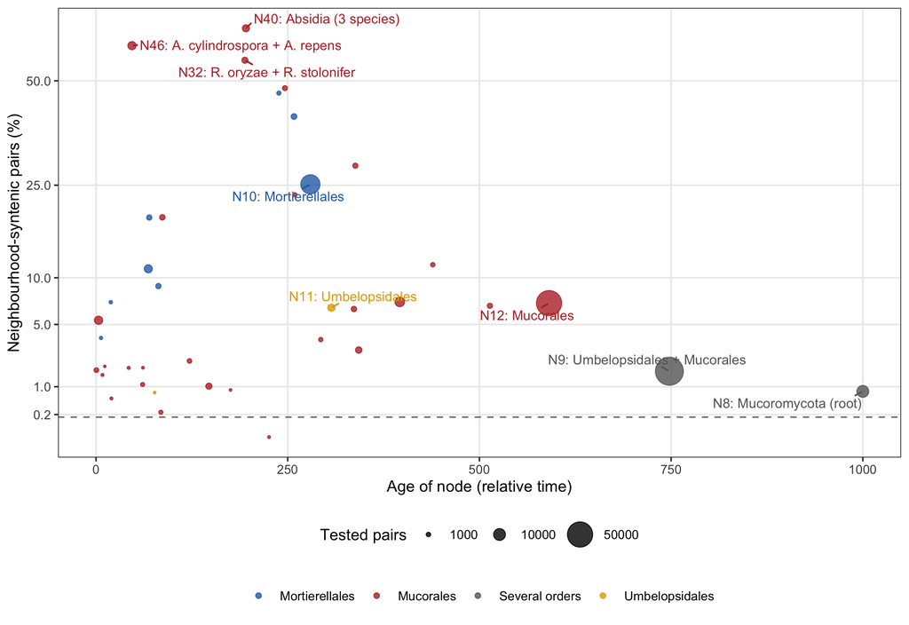

**Figure 16.** Percentage of neighbourhood-syntenic pairs (W = 10, k = 2) among the duplicates of each internal node against the age of the node (square-root scale). Nodes with at least 200 tested pairs. Dashed line: rate in genomes with shuffled gene order. Compare with the collinearity-based Figure 10.

```r
nba <- nb_w[ntips > 1 & !is.na(age_end) & tested_10 >= 200]
nb_chance <- nb[W == 10 & is_null == TRUE, 100 * mean(pass)]
ggplot(nba, aes(age_end, real_10, colour = clade_order)) +
  geom_hline(yintercept = nb_chance, linetype = "dashed", colour = "grey50") +
  geom_point(aes(size = tested_10), alpha = 0.8) +
  geom_text_repel(data = merge(nba, key_nodes, by = "node"), aes(label = paste0(node, ": ", label)),
                  size = 3, show.legend = FALSE, min.segment.length = 0) +
  scale_y_sqrt(breaks = c(0.2, 1, 5, 10, 25, 50)) +
  scale_colour_manual(values = c(order_cols, "Several orders" = "grey40"), name = NULL) +
  scale_size_area(max_size = 8, name = "Tested pairs", breaks = c(1000, 10000, 50000)) +
  labs(x = "Age of node (relative time)", y = "Neighbourhood-syntenic pairs (%)") +
  theme(legend.position = "bottom", legend.box = "vertical")
```

```r
nb_tab <- merge(key_nodes[node != "N8"], nb_w, by = "node", sort = FALSE)
nb_tab <- merge(nb_tab, nodes[, .(node, sd_share)], by = "node", sort = FALSE)
nb_tab <- nb_tab[, .(node, label, tested = tested_10, collinear_SD = round(100 * sd_share, 1),
                     syntenic = round(real_10, 1), chance = round(chance_10, 2),
                     enrichment = round(real_10 / chance_10), syntenic_W20 = round(real_20, 1),
                     syntenic_W30 = round(real_30, 1), events, events_syntenic = round(ev_real, 1),
                     events_chance = round(ev_chance, 1))]
knitr::kable(nb_tab, caption = tcap("nb_nodes", "Neighbourhood synteny of the duplicates of key branches. tested: duplicate pairs tested (W = 10). collinear_SD: % segmental pairs by doubletrouble's collinearity rule (Section 4.2). syntenic, chance: % neighbourhood-syntenic pairs (W = 10, k = 2) in the real genomes and with shuffled gene order; syntenic_W20, syntenic_W30: the same with W = 20, k = 3 and W = 30, k = 4. events_syntenic: % of the gene-tree duplications with a neighbourhood-syntenic pair in at least one descendant genome; events_chance: the same with shuffled gene order."))
```

Table 14. Neighbourhood synteny of the duplicates of key branches. tested: duplicate pairs tested (W = 10). collinear_SD: % segmental pairs by doubletrouble’s collinearity rule (Section 4.2). syntenic, chance: % neighbourhood-syntenic pairs (W = 10, k = 2) in the real genomes and with shuffled gene order; syntenic_W20, syntenic_W30: the same with W = 20, k = 3 and W = 30, k = 4. events_syntenic: % of the gene-tree duplications with a neighbourhood-syntenic pair in at least one descendant genome; events_chance: the same with shuffled gene order.

| node | label | tested | collinear_SD | syntenic | chance | enrichment | syntenic_W20 | syntenic_W30 | events | events_syntenic | events_chance |
| --- | --- | --- | --- | --- | --- | --- | --- | --- | --- | --- | --- |
| N9 | Umbelopsidales + Mucorales | 62080 | 0.1 | 1.7 | 0.16 | 11 | 1.3 | 1.2 | 763 | 34.1 | 11.6 |
| N12 | Mucorales | 50131 | 0.3 | 7.1 | 0.18 | 40 | 4.1 | 3.1 | 1256 | 50.7 | 6.9 |
| N11 | Umbelopsidales | 3274 | 0.3 | 6.6 | 0.13 | 52 | 5.6 | 5.4 | 512 | 12.5 | 0.9 |
| N10 | Mortierellales | 28076 | 14.9 | 25.2 | 0.17 | 146 | 30.1 | 33.1 | 1564 | 65.5 | 3.1 |
| N40 | Absidia (3 species) | 3132 | 29.0 | 65.8 | 0.12 | 567 | 61.4 | 56.4 | 1004 | 86.6 | 0.4 |
| N46 | A. cylindrospora + A. repens | 4426 | 28.1 | 60.4 | 0.16 | 384 | 56.8 | 52.4 | 1820 | 76.9 | 0.4 |
| N32 | R. oryzae + R. stolonifer | 2243 | 26.3 | 56.0 | 0.16 | 344 | 52.3 | 49.5 | 1041 | 79.3 | 0.4 |

## 6.3 Same genomes, different ages

Gene order is scrambled at different rates in different genomes, so the duplicates of different branches are best compared within the same genomes. For each younger Mucorales node, the genomes below it were taken, and the neighbourhood synteny of the node’s own duplicates was compared with that of the Mucorales-stem (N12) and N9 duplicates in the same genomes. Synteny only decays with time, so older duplicates that are more often syntenic than younger ones must more often have arisen in multi-gene (segmental or whole-genome) duplications.

```r
of_desc <- function(nd) extract.clade(of_tree, nt + match(nd, of_tree$node.label))$tip.label
real10 <- nbx[W == 10 & !is_null]
young <- nodes[clade_order == "Mucorales" & ntips > 2 & !is.na(age_end) & age_end < nv("N12", "age_end")]
same <- rbindlist(lapply(young$node, function(nd) {
  gs <- of_desc(nd); y <- real10[genome %in% gs]
  data.table(node = nd, genomes = length(gs), own_n = y[node == nd, .N],
             own = 100 * y[node == nd, mean(pass)], N12 = 100 * y[node == "N12", mean(pass)],
             N9 = 100 * y[node == "N9", mean(pass)])
}))[own_n >= 200]
same <- merge(same, nodes[, .(node, age_start, age_end)], by = "node")
# nodes on or next to the branches of the recent WGDs and the Lichtheimia signal
wgd_linked <- c("N40", "N23", "N31", "N45", "N37")
same[, group := fifelse(node %in% wgd_linked, "Near a recent WGD or the Lichtheimia signal", "Other")]
same[, lab := sprintf("%s (%.0f-%.0f; %d genomes)", node, age_end, age_start, genomes)]
same <- same[order(-age_start)]
```

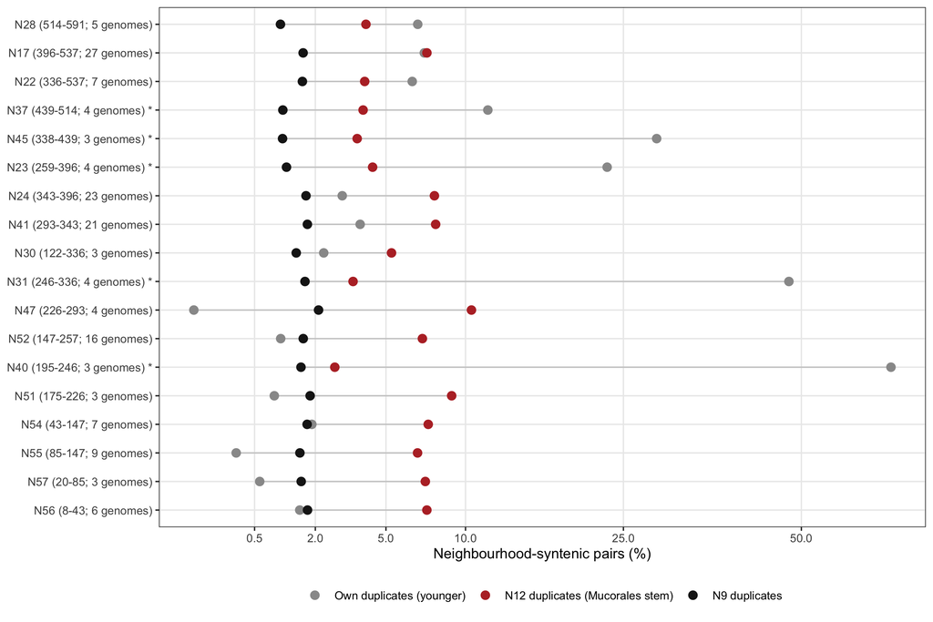

**Figure 17.** Neighbourhood-syntenic pairs (%) among the duplicates of younger Mucorales nodes (own) and among the Mucorales-stem (N12) and N9 duplicates in the same genomes. Each row: one node, with its age range (relative time) and the number of genomes below it. Rows marked with an asterisk are nodes on or next to the branches of the recent Absidia and Rhizopus WGDs or the Lichtheimia signal.

```r
sl <- melt(same[, .(lab, group, own, N12, N9)], id.vars = c("lab", "group"), variable.name = "dups", value.name = "pct")
sl[, lab := factor(ifelse(group == "Other", lab, paste0(lab, " *")),
                   rev(ifelse(same$group == "Other", same$lab, paste0(same$lab, " *"))))]
sl[, dups := factor(dups, c("own", "N12", "N9"), c("Own duplicates (younger)", "N12 duplicates (Mucorales stem)", "N9 duplicates"))]
ggplot(sl, aes(pct, lab)) +
  geom_line(aes(group = lab), colour = "grey80") +
  geom_point(aes(colour = dups), size = 2.5) +
  scale_x_sqrt(breaks = c(0.5, 2, 5, 10, 25, 50)) +
  scale_colour_manual(values = c("grey60", order_cols[["Mucorales"]], "grey10"), name = NULL) +
  labs(x = "Neighbourhood-syntenic pairs (%)", y = NULL) +
  theme(legend.position = "bottom")
```

## 6.4 Mucorales-stem duplications across genomes

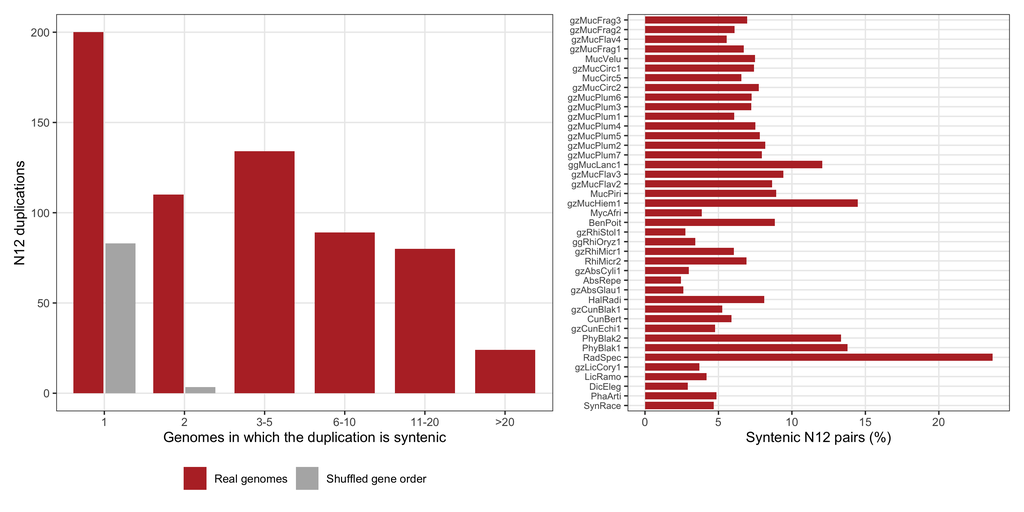

**Figure 18.** Left: number of Mucorales genomes in which a Mucorales-stem (N12) duplication has a neighbourhood-syntenic pair, for the real genomes and with shuffled gene order (mean of 3 shuffles); duplications syntenic in no genome are not shown. Right: neighbourhood-syntenic pairs (%) among the N12 duplicates in each Mucorales genome, in species-tree order.

```r
ev12 <- nbx[W == 10 & node == "N12", .(n_genomes = uniqueN(genome[pass])), by = .(event, run)]
ev12[, bin := cut(n_genomes, c(0, 1, 2, 5, 10, 20, Inf), labels = c("1", "2", "3-5", "6-10", "11-20", ">20"))]
evh <- ev12[n_genomes > 0, .N, by = .(bin, real = run == "real")][, N := ifelse(real, N, N / 3)]
evh[, set := factor(ifelse(real, "Real genomes", "Shuffled gene order"), c("Real genomes", "Shuffled gene order"))]
p_ev <- ggplot(evh, aes(bin, N, fill = set)) +
  geom_col(position = position_dodge(width = 0.8), width = 0.75) +
  scale_fill_manual(values = c(order_cols[["Mucorales"]], "grey70"), name = NULL) +
  labs(x = "Genomes in which the duplication is syntenic", y = "N12 duplications") +
  theme(legend.position = "bottom")
g12 <- real10[node == "N12", .(pct = 100 * mean(pass), n = .N), by = genome]
g12[, genome := factor(genome, tip_order)]
p_g <- ggplot(g12, aes(pct, genome)) +
  geom_col(fill = order_cols[["Mucorales"]], width = 0.75) +
  labs(x = "Syntenic N12 pairs (%)", y = NULL) +
  theme(axis.text.y = element_text(size = 6.5))
p_ev + p_g + plot_layout(widths = c(1.3, 1))
```

## 6.5 Ancestrally segmental duplications (ancientSD) and their Ks

A gene-tree duplication is *ancestrally segmental* (ancientSD) if, in at least two descendant genomes, one of its duplicate pairs is segmental (doubletrouble) or neighbourhood-syntenic (W = 10, k = 2), near-identical pairs excluded in both. All pairs of such a duplication, in every descendant genome, are then counted as ancientSD, including those now classified as dispersed: the duplication arose in a block, whatever its state today. Requiring two genomes keeps chance passes rare (Section 6.4). Their Ks distributions show whether these block duplications can be dated.

```r
nb_real10 <- nb[W == 10 & !is_null, .(genome, key, nb_pass = pass)]
anc <- merge(cross[, .(genome, key, node, event, type)], nb_real10, by = c("genome", "key"), all.x = TRUE)
pair_ks <- unique(pairs[, .(genome, key = paste(pmin(dup1, dup2), pmax(dup1, dup2)), Ks)], by = c("genome", "key"))
anc <- merge(anc, pair_ks, by = c("genome", "key"), all.x = TRUE)
# segmental pairs count only if not near-identical, as in the neighbourhood test
anc[, syn := (type %in% "SD" & !is.na(Ks) & Ks >= 0.05) | (!is.na(nb_pass) & nb_pass)]
anc <- merge(anc, anc[, .(syn_genomes = uniqueN(genome[syn])), by = event], by = "event")
anc[, cls := fcase(syn_genomes >= 2, "ancientSD", syn_genomes == 1, "Syntenic in 1 genome",
                   default = "No synteny")]
anc_nodes <- key_nodes[node != "N8"]
anc_ev <- unique(anc[, .(event, node, cls)])[node %in% anc_nodes$node,
  .(events = .N, ancientSD = sum(cls == "ancientSD")), by = node]
ksw <- anc[node %in% anc_nodes$node & !is.na(Ks) & Ks >= 0.05 & Ks <= 5]
ksw[, set := fifelse(cls == "ancientSD", "ancientSD", "other")]
anc_ks <- ksw[, .(pairs = .N, median_Ks = median(Ks), below2 = 100 * mean(Ks < 2),
                  window = 100 * mean(Ks > 1.5 & Ks < 2.6)), by = .(node, set)]
anc_ks_w <- dcast(anc_ks, node ~ set, value.var = c("pairs", "median_Ks", "below2", "window"))
anc_tab <- merge(anc_nodes, merge(anc_ev, anc_ks_w, by = "node"), by = "node", sort = FALSE)
anc_show <- anc_tab[, .(node, label, events, ancientSD_pct = round(100 * ancientSD / events),
                        ancientSD_pairs = pairs_ancientSD, median_Ks = round(median_Ks_ancientSD, 2),
                        Ks_below_2 = round(below2_ancientSD, 1),
                        Ks_1.5_2.6 = round(window_ancientSD, 1), Ks_1.5_2.6_other = round(window_other, 1))]
knitr::kable(anc_show, caption = tcap("anc", "Gene-tree duplications that are ancestrally segmental (ancientSD: segmental or neighbourhood-syntenic in at least two descendant genomes) on key branches, and the Ks of their duplicate pairs (Ks 0.05-5). Ks_below_2: % of ancientSD pairs with Ks < 2; Ks_1.5_2.6: % in the window of the Mortierellales Ks component (Section 3), for ancientSD pairs and for the other pairs of the same branch."))
```

Table 15. Gene-tree duplications that are ancestrally segmental (ancientSD: segmental or neighbourhood-syntenic in at least two descendant genomes) on key branches, and the Ks of their duplicate pairs (Ks 0.05-5). Ks_below_2: % of ancientSD pairs with Ks < 2; Ks_1.5_2.6: % in the window of the Mortierellales Ks component (Section 3), for ancientSD pairs and for the other pairs of the same branch.

| node | label | events | ancientSD_pct | ancientSD_pairs | median_Ks | Ks_below_2 | Ks_1.5_2.6 | Ks_1.5_2.6_other |
| --- | --- | --- | --- | --- | --- | --- | --- | --- |
| N9 | Umbelopsidales + Mucorales | 773 | 21 | 12915 | 4.02 | 2.0 | 4.5 | 4.5 |
| N12 | Mucorales | 1264 | 35 | 16395 | 4.06 | 2.4 | 4.6 | 3.8 |
| N11 | Umbelopsidales | 567 | 8 | 262 | 4.17 | 3.1 | 1.5 | 6.3 |
| N10 | Mortierellales | 1588 | 61 | 13992 | 4.12 | 6.1 | 11.1 | 5.7 |
| N40 | Absidia (3 species) | 1022 | 71 | 2209 | 1.92 | 54.0 | 50.0 | 36.3 |
| N46 | A. cylindrospora + A. repens | 1943 | 58 | 2493 | 1.63 | 68.1 | 42.2 | 30.0 |
| N32 | R. oryzae + R. stolonifer | 1094 | 37 | 855 | 2.28 | 41.1 | 37.1 | 34.0 |

The ancientSD duplications of the two stems, counted as duplications (gene-tree events), as the genes that descend from them in today’s genomes, and as copy pairs (one copy from each side of a duplication, within a genome) with their current doubletrouble classification (Table 16).

```r
stems <- data.table(node = c("N12", "N10"), stem = c("Mucorales stem (N12)", "Mortierellales stem (N10)"))
ac <- anc[node %in% stems$node]
ac_ev <- unique(ac[, .(node, event, cls)])[, .(duplications = .N, ancientSD = sum(cls == "ancientSD")), by = node]
ac_sd <- ac[cls == "ancientSD"]
ac_genes <- ac_sd[, .(genes = uniqueN(c(paste(genome, sub(" .*", "", key)), paste(genome, sub(".* ", "", key)))),
                      genomes = uniqueN(genome), pairs = .N, classified = sum(!is.na(type)),
                      SD = sum(type %in% "SD"), TD = sum(type %in% "TD"), PD = sum(type %in% "PD"),
                      DD = sum(type %in% "DD")), by = node]
anc_counts <- merge(stems, merge(ac_ev, ac_genes, by = "node"), by = "node", sort = FALSE)
anc_counts_show <- anc_counts[, .(
  stem, `supported duplications` = fmt_n(duplications),
  `ancientSD duplications` = sprintf("%s (%.0f%%)", fmt_n(ancientSD), 100 * ancientSD / duplications),
  `descendant genes` = sprintf("%s (%d genomes)", fmt_n(genes), genomes),
  `copy pairs` = fmt_n(pairs), classified = fmt_n(classified),
  SD = sprintf("%s (%.0f%%)", fmt_n(SD), 100 * SD / classified),
  TD = fmt_n(TD), PD = fmt_n(PD),
  DD = sprintf("%s (%.0f%%)", fmt_n(DD), 100 * DD / classified))]
knitr::kable(anc_counts_show, caption = tcap("anc_counts", "ancientSD duplications on the Mucorales and Mortierellales stems. Supported duplications: OrthoFinder gene-tree duplications on the stem with at least 50% support. Descendant genes: present-day copies descending from the ancientSD duplications, summed over genomes. Copy pairs: pairs of copies from the two sides of each duplication within a genome; classified: pairs that doubletrouble classified (the others were not among either gene's top 5 within-genome DIAMOND hits), with their current mode (% of classified pairs)."))
```

Table 16. ancientSD duplications on the Mucorales and Mortierellales stems. Supported duplications: OrthoFinder gene-tree duplications on the stem with at least 50% support. Descendant genes: present-day copies descending from the ancientSD duplications, summed over genomes. Copy pairs: pairs of copies from the two sides of each duplication within a genome; classified: pairs that doubletrouble classified (the others were not among either gene’s top 5 within-genome DIAMOND hits), with their current mode (% of classified pairs).

| stem | supported duplications | ancientSD duplications | descendant genes | copy pairs | classified | SD | TD | PD | DD |
| --- | --- | --- | --- | --- | --- | --- | --- | --- | --- |
| Mucorales stem (N12) | 1,264 | 442 (35%) | 30,071 (41 genomes) | 19,302 | 17,073 | 149 (1%) | 152 | 92 | 16,680 (98%) |
| Mortierellales stem (N10) | 1,588 | 969 (61%) | 25,810 (13 genomes) | 26,342 | 15,019 | 4,346 (29%) | 314 | 384 | 9,975 (66%) |

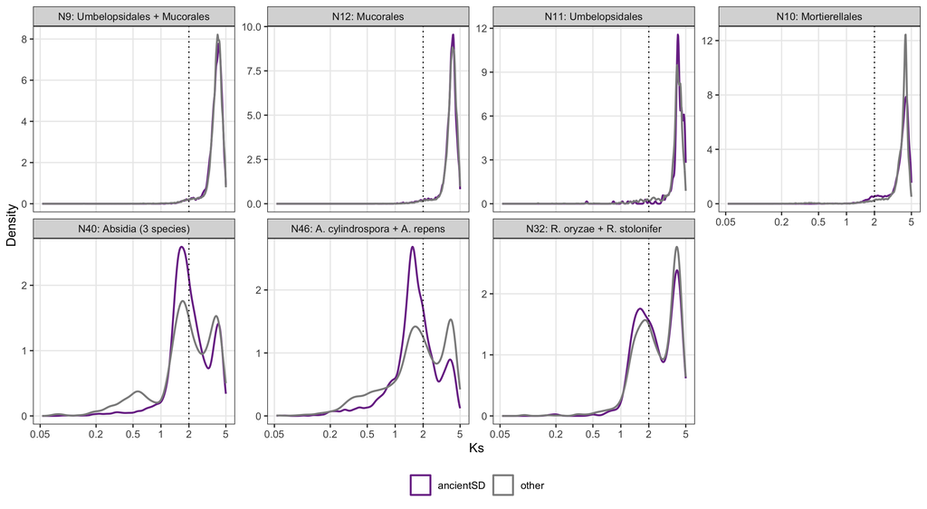

**Figure 19.** Ks distributions (log scale, Ks 0.05-5) of the duplicate pairs of key branches, for ancientSD duplications and for the other duplications of the same branch (density curves). Dotted line: Ks = 2.

```r
ksw <- merge(ksw, anc_nodes, by = "node")
ksw[, panel := factor(paste0(node, ": ", label), paste0(anc_nodes$node, ": ", anc_nodes$label))]
ggplot(ksw, aes(Ks, colour = set)) +
  geom_density(adjust = 0.8, linewidth = 0.7) +
  geom_vline(xintercept = 2, linetype = "dotted") +
  facet_wrap(~panel, ncol = 4, scales = "free_y") +
  scale_x_log10(breaks = c(0.05, 0.2, 0.5, 1, 2, 5), labels = c(0.05, 0.2, 0.5, 1, 2, 5)) +
  scale_colour_manual(values = c(ancientSD = accent, other = "grey55"), name = NULL) +
  labs(x = "Ks", y = "Density") +
  theme(legend.position = "bottom", strip.text = element_text(size = 8))
```

## 6.6 Conclusion

```r
cb <- function(o, col) calib[W == 10 & order == o][[col]]
nw <- function(nd, col) nb_w[node == nd][[col]]
ev12_real <- ev12[run == "real"]
ev12_multi <- ev12_real[, mean(n_genomes >= 2)]
ev12_multi_null <- ev12[run != "real", mean(n_genomes >= 2)]
other <- same[group == "Other"]
n_older_wins <- other[, sum(N12 > own)]
n_n9_lower <- same[, sum(N9 < N12)]
av <- function(nd, col) anc_show[node == nd][[col]]
acn <- function(nd, col) fmt_n(anc_counts[node == nd][[col]])
wgd_genomes <- c("gzAbsCyli1", "AbsRepe", "gzAbsGlau1", "ggRhiOryz1", "gzRhiStol1")
n12_wo_wgd <- 100 * real10[node == "N12" & !genome %in% wgd_genomes, mean(pass)]
top_g <- g12[order(-pct)][1:3]
gname <- function(g) gen$species[match(g, gen$genome)]
rng <- function(v, d = 1) paste(sprintf(paste0("%.", d, "f"), range(v)), collapse = "-")
```

- **The test is specific and sensitive.** With shuffled gene order only 0.14-0.16% of pairs pass, whereas 77-89% of doubletrouble’s segmental pairs in Mortierellales and Mucorales do (Table 13).
- **Many “dispersed” duplicates are eroded segmental duplicates.** 3.7% of the dispersed pairs in Mucorales and 6.3% in Mortierellales are neighbourhood-syntenic, 23 and 39 times the chance rate.
- **The Mucorales-stem duplicates are syntenic far above chance.** 7.1% of the N12 pairs pass, 40 times the chance rate, against 1.7% for the older N9 duplicates; the result holds with the wider windows (Table 14, Figure 16). 50.7% of the N12 duplications are syntenic in at least one Mucorales genome (chance 6.9%), and 35% in two or more (chance 0.3%), while the same duplications are dispersed in other genomes (Figure 18). The genomes that keep the most are those of Radiomyces spectabilis (24%), Mucor hiemalis (14%), Phycomyces blakesleeanus (14%).
- **They are more syntenic than younger duplicates in the same genomes.** In 11 of 13 younger Mucorales nodes (excluding those next to the recent WGDs and the *Lichtheimia* signal), the N12 duplicates are more often syntenic than the node’s own, younger duplicates in the same genomes (Figure 17), and the older N9 duplicates are less syntenic than the N12 duplicates in 18 of 18. Since synteny decays with time, the Mucorales-stem duplications must more often have arisen as multi-gene duplications than the later duplications in the same genomes. The signal does not come from duplicates of the recent WGDs being misplaced on N12: without the *Absidia* and *Rhizopus* genomes, 7.8% of the N12 pairs are syntenic.
- **Mortierellales.** 25.2% of the Mortierellales-stem duplicates are neighbourhood-syntenic, more than with the collinearity rule (14.9%), consistent with a large-scale duplication early in the order.
- **Ancestrally segmental duplications.** 442 of the 1,264 Mucorales-stem duplications (35%) and 969 of the 1,588 Mortierellales-stem duplications (61%) are ancientSD, with 30,071 and 25,810 descendant genes (Table 16). Of the classified Mucorales-stem pairs, 98% are now dispersed, against 66% on the Mortierellales stem. The Mucorales-stem pairs are saturated (median Ks 4.06; 2.4% below 2): Ks cannot date this event even when restricted to block duplicates (Table 15, Figure 19). The ancientSD pairs of the Mortierellales stem are enriched in the Ks 1.5-2.6 window (11.1% against 5.7% for the other stem duplicates), so the Ks component shared by all Mortierellales genomes (Section 3) most likely reflects this event. If substitution rates are similar in the two orders, it is younger than the Mucorales-stem event, perhaps late on the long Mortierellales stem.
- **What this adds.** With collinearity, the Mucorales-stem burst showed no sign of block duplication. With an order-free measure it does: its duplicates arose in duplicated regions far more often than expected by chance and than later duplicates, but are now scattered because gene order has been scrambled since. Together with the breadth of the burst and the parallel retention of copies (Section 4), this is the evidence for a large-scale duplication, most simply a WGD, on the Mucorales stem. It does not exclude several large segmental duplications on that branch, which a model-based test (e.g. Whale) could address.

# Summary

- **Genome set.** Most of the 61 assemblies are contiguous enough to detect collinear duplicates. gzMucFlav4 likely contains duplicated assembly sequences, and near-identical pairs are treated separately throughout.
- **Duplicate landscape.** 50-72% of genes are in paralogous pairs in each genome, mostly as dispersed duplicates. Collinear (segmental) duplicates are common only in Mortierellales and in *Absidia* and *Rhizopus*. In other Mucorales and in Umbelopsidales they are rare even in chromosome-level assemblies, and in Mucorales a large share of them are near-identical.
- **Gene number.** Larger gene sets come mainly from more dispersed duplicates, except in *Absidia* and *Rhizopus*, where many extra genes are segmental duplicates (candidate lineage-specific WGDs).
- **Recent lineage-specific WGDs.** *Absidia* and *Rhizopus oryzae* have segmental Ks peaks at about Ks 1.6-1.9, younger than the split of the two genera, so they are two independent events. The *Absidia* event is shared by *A. cylindrospora* and *A. repens* (and perhaps *A. glauca*); the *Rhizopus* event is shared by *R. oryzae* and *R. stolonifer*, postdates the split from *R. microsporus* and probably matches the WGD known from *R. delemar*.
- **The proposed early WGD.** Gene trees show a burst of duplications on the Mucorales stem (3.7 times the median rate), not on the branch shared with Umbelopsidales. The burst is spread across many gene families and its copies were retained in parallel across Mucorales, as after a WGD. Ks is saturated at that age, there is no macrosynteny between the orders for a 1:2 test, and the duplicates are no longer collinear: families expanded in Mucorales gained dispersed copies, not tandem arrays.
- **Synteny without gene order.** Many “dispersed” duplicates are eroded segmental duplicates. Measured without gene order, the Mucorales-stem duplicates still lie in duplicated neighbourhoods 40 times more often than by chance, half of these duplications are syntenic in at least one Mucorales genome, and they are more syntenic than younger duplicates in the same genomes. They therefore arose in multi-gene duplications, and their collinearity was lost later through the scrambling of gene order. With the breadth and parallel retention of the burst, this makes a large-scale duplication on the Mucorales stem, most simply the WGD proposed by Corrochano et al., the best explanation; a model-based test (Whale) could still separate a single WGD from several large segmental duplications. Families expanded in *Absidia* and *Rhizopus* are still largely in collinear blocks.
- **Mortierellales.** Collinear and neighbourhood-syntenic duplicates mapped to the Mortierellales stem and earliest nodes, and collinear expansions of gene families, suggest a large-scale duplication on the Mortierellales stem. Its ancestrally segmental duplicates make up the Ks component near 2.4 shared by all Mortierellales genomes, whereas those of the Mucorales stem are saturated, so the Mortierellales event is probably the younger of the two.